# Assignment 2

## B159640

This Rmarkdown document provides answers, tables and graphs for the problems 1-4 and the R code used to obtain them. It is recommended to knit the Rmarkdown to HTML to obtain the intended formatting.

### Problem 1

Loading datasets `lipids.txt` and `lipid-classes.txt` required for problem 1

```r
# load library to work with data tables (also for all following problems)
library(data.table)

# import file and look up files
lipids.dt <- fread("lipids.txt", stringsAsFactors = TRUE)
lipid.classes.dt <- fread("lipid-classes.txt", stringsAsFactors = TRUE)
```

#### Problem 1 (a)

Using the lipid-class lookup table `lipid.classes.dt` to determine the lipid classes of the lipid species listed `lipids.dt`, then adding a new lipid class colum to `lipids.dt`:

Writing a function to classify the lipids in a given data table. It accepts as input a data table `lipid.table`, a string `lipid.species.col` that specifies the column of `lipid.table` in which the lipid species are stored and a vector `lipid.classes`:

```r
classify.lipids <- function(lipid.table, lipid.species.col, lipid.classes){

  # add  class colum to lipid.table
  lipid.table[, lipid.class := NA]

  # loop over over all lipid classes

  for(lipid in lipid.classes){

    # create regex that finds all lipid class identifiers
    regex <- paste0("(\\s|^)[",
                    toupper(substr(lipid,1,1)),
                    tolower(substr(lipid,1,1)),
                    "](",
                    toupper(substr(lipid,2,nchar(lipid))),
                    "|",
                    tolower(substr(lipid,2,nchar(lipid))),
                    ")(\\s|$)")

    # add new col lipid.class to lipid.dt

    lipid.species <- paste0(lipid.table, "$" , lipid.species.col)
    lipid.table[, lipid.class := ifelse(grepl(regex, lipid.species), lipid, lipid.class)]
  }
}
```

Classifying the lipids:

```r
classify.lipids(lipids.dt, "lipid.species" , lipid.classes.dt$CE)
```

Checking the results:

```r
head(lipids.dt, n = 15)
```

```
##        lipid.species oddsratio      se lipid.class
##  1:          PC 34:6      1.79 0.13662          PC
##  2:          PC 34:5      0.74 0.12452          PC
##  3: 18:2 820 TAG C48      0.89 0.12213         TAG
##  4: 16:2 870 TAG C52      0.78 0.12435         TAG
##  5: 16:1 842 TAG C50      0.92 0.11752         TAG
##  6:          PC 42:5      0.90 0.12413          PC
##  7:          PC 32:4      0.97 0.12601          PC
##  8:          CE 18:2      1.06 0.12881        <NA>
##  9: 18:1 800 tag C52      1.03 0.13525         TAG
## 10: 20:2 928 TAG C56      0.98 0.13847         TAG
## 11: 16:2 872 TAG C52      0.83 0.12817         TAG
## 12: 14:0 872 TAG C52      0.85 0.12010         TAG
## 13:   PE 38p:5 750.6      0.93 0.11500          PE
## 14: 16:1 902 TAG C54      0.84 0.12082         TAG
## 15:          PC 38:3      1.08 0.12907          PC
```

Ooops, the function fails to classify lipids species containing the label “CE”. There are two possible reasons for this:

- the label “CE” and “Cer” tag Cholesterylester
- the label “CE” is the identifier of an ester not listed in `lipid.classed.dt`

A quick google search leads to the [LIPID MAPS® Lipidomics Gateway website](https://www.lipidmaps.org/tools/ms/lm_mass_form.php) which provides access to lipid nomenclature, databases, tools, protocols and many more to serve the international lipid research community. Here, we learn that “CE” is the identifier for lipids belonging to the class Cholesterylester. Hence, we add this label to `lipid.classes.dt`:

```r
lipid.classes.dt <- rbind(lipid.classes.dt, list("CE", "Cholesterylesters"))
```

Rerunning the classification function:

```r
classify.lipids(lipids.dt, "lipid.species" , lipid.classes.dt$CE)
```

Checking the results (again):

```r
head(lipids.dt, n = 15)
```

```
##        lipid.species oddsratio      se lipid.class
##  1:          PC 34:6      1.79 0.13662          PC
##  2:          PC 34:5      0.74 0.12452          PC
##  3: 18:2 820 TAG C48      0.89 0.12213         TAG
##  4: 16:2 870 TAG C52      0.78 0.12435         TAG
##  5: 16:1 842 TAG C50      0.92 0.11752         TAG
##  6:          PC 42:5      0.90 0.12413          PC
##  7:          PC 32:4      0.97 0.12601          PC
##  8:          CE 18:2      1.06 0.12881          CE
##  9: 18:1 800 tag C52      1.03 0.13525         TAG
## 10: 20:2 928 TAG C56      0.98 0.13847         TAG
## 11: 16:2 872 TAG C52      0.83 0.12817         TAG
## 12: 14:0 872 TAG C52      0.85 0.12010         TAG
## 13:   PE 38p:5 750.6      0.93 0.11500          PE
## 14: 16:1 902 TAG C54      0.84 0.12082         TAG
## 15:          PC 38:3      1.08 0.12907          PC
```

Merging the data tables and counting the number of lipids that fall in each class

```r
results.dt <- merge(lipids.dt, lipid.classes.dt,
                    by.x = "lipid.class",
                    by.y = "CE" )

table(results.dt$`Cholesterol esters`)
```

```
##
##                     Ceramides               Diacylglycerols
##                            13                            16
##      Lysophosphatidylcholines Lysophosphatidylethanolamines
##                            13                             3
##          Phosphatidylcholines     Phosphatidylethanolamines
##                            42                            25
##           Phosphatidylserines                Sphingomyelins
##                             8                             0
##              Triacylglycerols             Cholesterylesters
##                           147                             9
```

#### Problem 1 (b)

Computing the wald test statistic for each lipid species:

```r
results.dt[, "wald.test" := round((oddsratio-1)/se,3)]
```

```r
results.dt[, "p.value(t-distn)" := signif(1-(pt(abs(wald.test), 277)-pt(-abs(wald.test), 277)),3)]
```

Computing a p-value for each lipid species using the normal distribution and append them to `results.dt`:

```r
results.dt[, "p.value(n-distn)" := signif(1-(pnorm(abs(wald.test))-pnorm(-abs(wald.test))),3)]
```

Checking the results:

```r
head(results.dt)
```

```
##    lipid.class lipid.species oddsratio      se Cholesterol esters wald.test
## 1:          CE       CE 18:2      1.06 0.12881  Cholesterylesters     0.466
## 2:          CE       CE 16:1      1.11 0.12886  Cholesterylesters     0.854
## 3:          CE       CE 20:4      0.92 0.13149  Cholesterylesters    -0.608
## 4:          CE       CE 18:3      1.16 0.12524  Cholesterylesters     1.278
## 5:          CE       CE 18:0      0.99 0.08333  Cholesterylesters    -0.120
## 6:          CE       CE 14:1      0.92 0.12219  Cholesterylesters    -0.655
##    p.value(t-distn) p.value(n-distn)
## 1:            0.642            0.641
## 2:            0.394            0.393
## 3:            0.544            0.543
## 4:            0.202            0.201
## 5:            0.905            0.904
## 6:            0.513            0.512
```

Providing some evidence to justify if the normal approximation is acceptable in this instance:

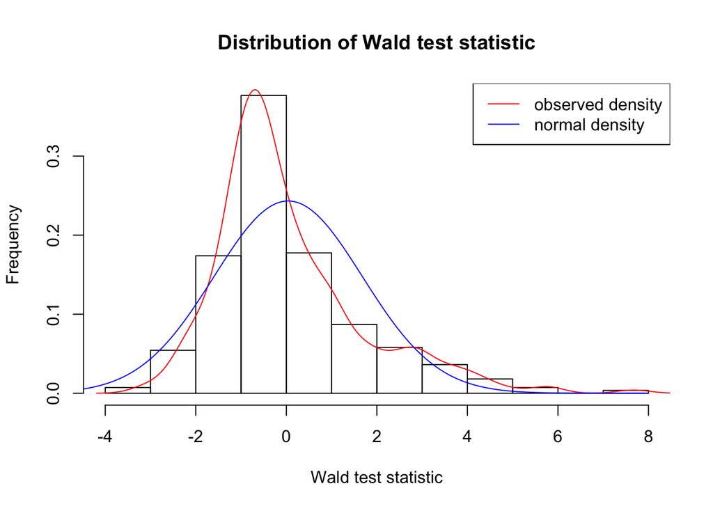

```r
hist(results.dt$wald.test,
     breaks = 12,
     freq=F,
     main = "Distribution of Wald test statistic",
     xlab = "Wald test statistic",
     ylab = "Frequency")

lines(density(results.dt$wald.test), col="red")

lines(seq(-8, 8, by=.05),
      dnorm(seq(-8, 8, by=.05), mean(results.dt$wald.test), sd(results.dt$wald.test)),
      col="blue")

legend("topright", c("observed density", "normal density"), col = c("red","blue"), lty = c(1,1))
```

Comparing the observed distribution with a normal distribution, it can be stated that the observed distribution deviates from the normal distn due to a higher leftwards-shifted peak and positive skewedness. However, the normal distribution is still acceptable as a rough approximation since we only care about the extreme values (tails or the distn) when computing a p-value and evaluating whether it is above or below a certain threshold (e.g. 0.05 or 0.01).

#### Problem (c)

Implementing a function `holm.bonferroni(results.dt, alpha)` that takes as input an data.table containing the hypotheses tested and corresponding p-values (`results.dt`) and the desired significance level (`alpha`). It computes the family-wise error rate for all hypotheses and returns `fwer.results.dt`a data table containing the subset of the tested hypothesis that are significant according to the Holm-Bonferroni method (FWER < `alpha`) ordered by increasing p-value.

```r
holm.bonferroni <- function(results.dt, alpha=0.05){

  # sorting p-values: assuming hypotheses are in the first column, p-values in the second column
  # rename columns
  colnames(results.dt) <- c('hypothesis','p.value')
  # sort results by p-value
  setorder(results.dt, cols = 'p.value')

  # variables

  m <- length(results.dt$p.value)
  k <- 1

  # loop over all p-values
  for (p.k in results.dt$p.value){

    # reject yes/no?
    if(p.k < alpha/(m+1-k)){
      #print(k)
      #print(p.k)
      k <- k + 1
    }else{
      break
    }
  }

  # subset output data table
  fwer.results.dt <- results.dt[1:k-1,]

  # order output data table
  setorder(fwer.results.dt, cols = 'p.value')

  # return result
  return(fwer.results.dt)
}
```

#### Problem (d)

Implementing a similiar function `benjamini.hochberg(results.dt, q)` that takes as input an data.table containing the hypotheses tested and corresponding p-values (`results.dt`) and and a false discovery rate `q`. It computes the false-discovery rate for all hypotheses and returns `fdr.results.dt` a data table containing the subset of hypothesis that are significant according to the Benjamini-Hochberg method (FDR < `q`) ordered by increasing p-value.

```r
benjamini.hochberg <- function(results.dt, q=0.05){

  # sorting p-values: assuming hypotheses are in the first column, p-values in the second column
  # rename columns
  colnames(results.dt) <- c('hypothesis','p.value')
  # sort results by p-value
  setorder(results.dt, cols = 'p.value')

  # variables

  m <- length(results.dt$p.value)
  k <- 1

  # loop over all p-values
  for (p.k in results.dt$p.value){

    # reject yes/no?
    if(p.k < (k/m*q)){
      #print(k)
      #print(p.k)
      k <- k + 1
    }else{
      break
    }
  }

  # subset output data table
  fdr.results.dt <- results.dt[1:k-1,]

  # order output data table
  setorder(fdr.results.dt, cols = 'p.value')

  # return result
  return(fdr.results.dt)
}
```

#### Problem 1 (e)

Producing a volcano plot using a different

- colour for the lipid species that are significant after controlling for the family-wise error rate at α = 0.05
- symbol to highlight the lipid species that are considered significant according to the Benjamini-Hochberg procedure at a false discovery rate of 1%

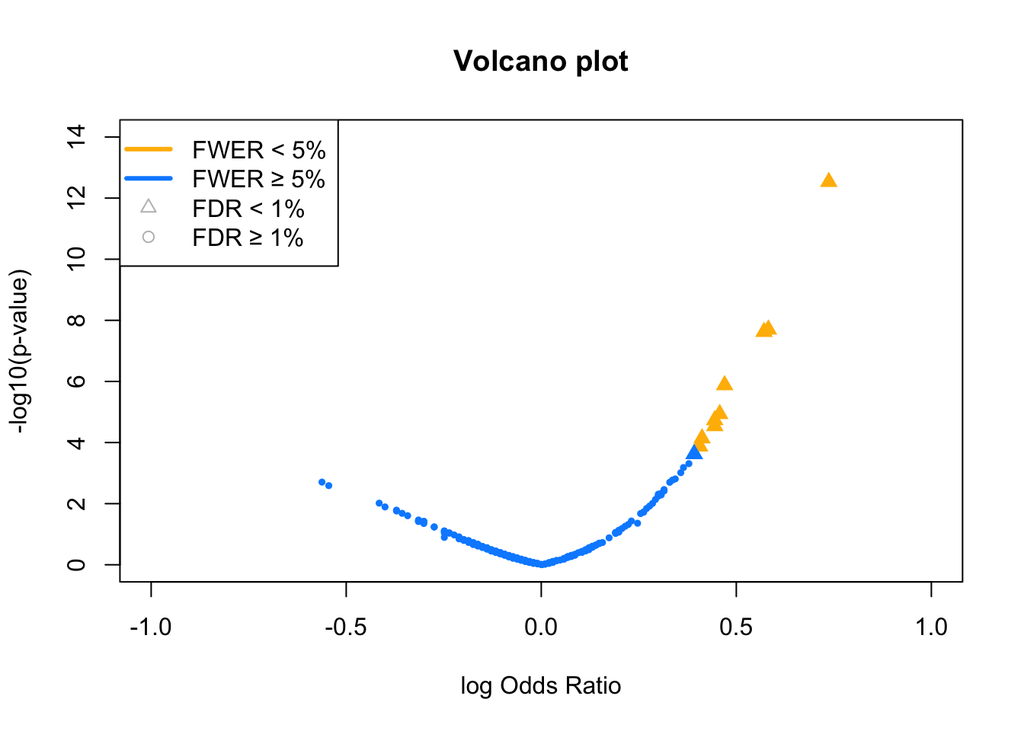

```r
# creating a data table `lipids.results.dt` that only contains the lipid species tested and their corresponding p-values (t-distn)
lipids.hypotheses.dt <- results.dt[,c('lipid.species','p.value(t-distn)')]

# determining significant subsets of lipid species according to both methods at given thresholds
fwer.dt <- holm.bonferroni(lipids.hypotheses.dt, 0.05)
fdr.dt <- benjamini.hochberg(lipids.hypotheses.dt, 0.01)

#plotting results
plot(log(results.dt$oddsratio), -log10(results.dt$`p.value(t-distn)`),
     main="Volcano plot",
     xlab="log Odds Ratio",
     ylab="-log10(p-value)",
     col=ifelse(results.dt$`p.value(t-distn)` %in% fwer.dt$p.value , "#FFB900FF","#008EFFFF"),
     pch=ifelse(results.dt$`p.value(t-distn)` %in% fdr.dt$p.value, 17, 19),
     cex=ifelse((results.dt$`p.value(t-distn)` %in% fdr.dt$p.value | results.dt$`p.value(t-distn)` %in% fwer.dt$`p.value(t-distn)`), 1.2, 0.5),
     xlim=c(-1,1),
     ylim=c(0,14))

# adding legend
legend("topleft", c("FWER < 5%", "FWER ≥ 5%", "FDR < 1%", "FDR ≥ 1%"),
       col = c("#FFB900FF","#008EFFFF", "grey", "grey"),
       lwd = c(3,3,1,1),
       lty = c(1,1,NA,NA),
       pch = c(NA,NA,2,1))
```

#### Problem 1 (f)

Applying the `holm.bonferroni()` function to data table `lipids.results.dt` in order to determine the significant subsets of lipid species according to Holm-Bonferroni method:

```r
holm.bonferroni(lipids.hypotheses.dt, 0.05) # significance level alpha = 0.05
```

```
##     hypothesis  p.value
##  1:    PS 36:4 2.94e-13
##  2:    PC 34:6 1.99e-08
##  3:    PS 38:5 2.38e-08
##  4:    PC 34:2 1.32e-06
##  5:    PC 36:2 1.16e-05
##  6:    PS 38:6 1.84e-05
##  7:    PS 38:4 2.89e-05
##  8:    PS 40:6 7.24e-05
##  9:    PC 42:1 1.31e-04
## 10:    PC 34:0 1.33e-04
```

Applying the `benjamini.hochberg()` function in order to determine the significant subsets of lipid species according to the Benjamini-Hochberg procedure:

```r
benjamini.hochberg(lipids.hypotheses.dt, 0.05)
```

```
##            hypothesis  p.value
##  1:           PS 36:4 2.94e-13
##  2:           PC 34:6 1.99e-08
##  3:           PS 38:5 2.38e-08
##  4:           PC 34:2 1.32e-06
##  5:           PC 36:2 1.16e-05
##  6:           PS 38:6 1.84e-05
##  7:           PS 38:4 2.89e-05
##  8:           PS 40:6 7.24e-05
##  9:           PC 42:1 1.31e-04
## 10:           PC 34:0 1.33e-04
## 11:           PC 36:3 2.36e-04
## 12:           PS 34:4 2.38e-04
## 13:           PS 40:5 4.90e-04
## 14: PE 36:2 p:2 728.6 6.57e-04
## 15:           PC 36:1 9.69e-04
## 16:           PC 32:0 1.55e-03
## 17: PE 36:1 p:1 730.6 1.69e-03
## 18:          LPC 14:0 1.97e-03
## 19:  14:1 842 TAG C50 2.00e-03
## 20:          LPC 22:6 2.57e-03
## 21:    PE 40p:0 788.6 3.46e-03
## 22:    PE 34a:1 718.6 3.84e-03
##            hypothesis  p.value
```

Determining the subset of lipid species that are significant according to both the Holm-Bonferroni method and the Benjamini-Hochberg procedure:

```r
fwer.dt <- holm.bonferroni(lipids.hypotheses.dt, 0.05)
fdr.dt <- benjamini.hochberg(lipids.hypotheses.dt, 0.05)
intersect(fwer.dt$hypothesis, fdr.dt$hypothesis)
```

```
##  [1] "PS 36:4" "PC 34:6" "PS 38:5" "PC 34:2" "PC 36:2" "PS 38:6" "PS 38:4"
##  [8] "PS 40:6" "PC 42:1" "PC 34:0"
```

### Problem 2

Loading the breast cancer dataset `wdbc2.csv` required for problem 2

```r
bc.dt <- fread("wdbc2.csv", stringsAsFactors = TRUE)
```

#### Problem 2 (a)

Using package `caret`, creating a data partition so that the training set contains 70% of the observations (and of course setting the random seed to 1 beforehand):

```r
library(caret)
set.seed(1)
train.idx <- createDataPartition(bc.dt$diagnosis, p=0.7)$Resample1
```

Fitting both a ridge regression model and a lasso model on the training set in order to diagnose the type of tumour from the 30 imaging biomarkers contained in the dataset:

Loading the `glmnet` package for ridge regression and LASSO regularization:

```r
library(glmnet)
```

Function to transform a dataframe to a matrix as expected by the glmnet package:

```r
prepare.glmnet <- function(data, formula=~ .){

  # create the design matrix to deal correctly with factor variables,
  # without losing rows containing NAs
  old.opts <- options(na.action='na.pass')
  x <- model.matrix(formula, data)
  options(old.opts)

  # remove the intercept column, as glmnet will add one by default
  x <- x[, -match("(Intercept)", colnames(x))]
  return(x)
}
```

Transforming the data

```r
# predictors
x.bc.dt <- prepare.glmnet(bc.dt[,!"id"], ~ . - diagnosis) # exclude the outcome
# outcome
y.bc.dt <- bc.dt$diagnosis
```

Fit both a ridge regression model and a lasso model on the training set to diagnose the type of tumour from the 30 biomarkers

```r
# ridge regression
bc.ridge <- glmnet(x.bc.dt, y.bc.dt, alpha=0, subset = train.idx, family="binomial")
# lasso regression
bc.lasso <- glmnet(x.bc.dt, y.bc.dt, subset = train.idx, family="binomial")
```

Plotting the trajectories of the coefficients for various lambda λ:

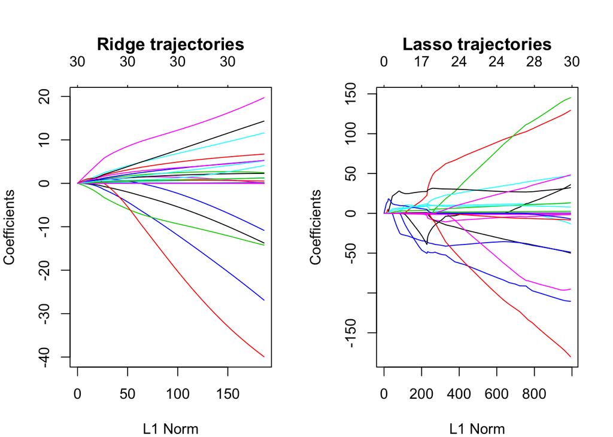

```r
par(mfrow=c(1,2), mar=c(4,4,5,2))
plot(bc.ridge, main="Ridge trajectories")
plot(bc.lasso, main="Lasso trajectories")
```

For each model learning by cross-validation the penalty parameter λ that maximizes the AUC:

```r
# ridge regression
bc.cv.ridge <- cv.glmnet(x.bc.dt, y.bc.dt, subset = train.idx, family="binomial", type.measure="auc", alpha=0)
# lasso regression
bc.cv.lasso <- cv.glmnet(x.bc.dt, y.bc.dt, subset = train.idx, family="binomial", type.measure="auc")
```

Plotting the cross-validation curve:

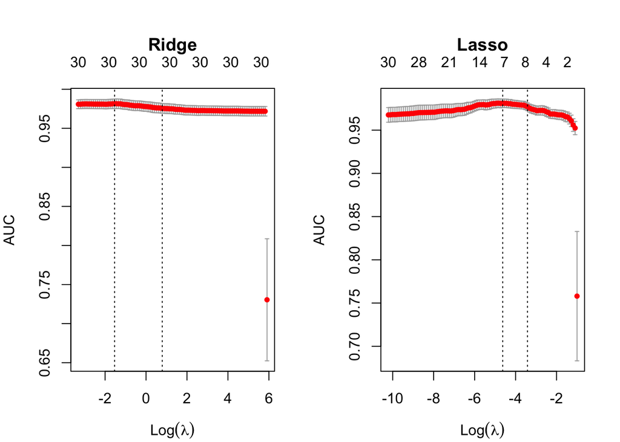

```r
par(mfrow=c(1,2), mar=c(4,4,5,2))
plot(bc.cv.ridge, main="Ridge")
plot(bc.cv.lasso, main="Lasso")
```

Penalty parameters λ that maximizes the AUC

```r
# ridge regression
bc.cv.ridge$lambda.min # this is admittedly counterintuitive
```

```
## [1] 0.2154996
```

```r
# lasso regression
bc.cv.lasso$lambda.min # this is admittedly counterintuitive
```

```
## [1] 0.009772645
```

#### Problem 2 (b)

For both models fitted in (a) extract the AUCs corresponding to the optimal λ:

There are two ways to this:

1. the optimal λ maximzes the AUC, so we just extract the maximal AUC

```r
# ridge
max(bc.cv.ridge$cvm)
```

```
## [1] 0.9814813
```

```r
# lasso
max(bc.cv.lasso$cvm)
```

```
## [1] 0.9811505
```

2. extract the AUC from the field `cvm` of the fit corresponding to the optimal λ (`lamda.min`) from the field `lambda` of the fit:

```r
# ridge
bc.cv.ridge$cvm[which(bc.cv.ridge$lambda == bc.cv.ridge$lambda.min)]
```

```
## [1] 0.9814813
```

```r
# lasso
bc.cv.lasso$cvm[which(bc.cv.lasso$lambda == bc.cv.lasso$lambda.min)]
```

```
## [1] 0.9811505
```

Extracting the AUCs corresponding to all λ where the corresponding AUC is within 1 standard error of the maximum AUC.

```r
# ridge
bc.cv.ridge$cvm[which(bc.cv.ridge$lambda <= bc.cv.ridge$lambda.1se)]
```

```
##  [1] 0.9754787 0.9758581 0.9761111 0.9761111 0.9764140 0.9766819 0.9772189
##  [8] 0.9774795 0.9777372 0.9778839 0.9781530 0.9785563 0.9788254 0.9789579
## [15] 0.9788254 0.9790873 0.9793479 0.9796186 0.9801418 0.9804182 0.9804182
## [22] 0.9808174 0.9813471 0.9813471 0.9814789 0.9814813 0.9813512 0.9810946
## [29] 0.9810999 0.9808380 0.9808055 0.9809433 0.9809433 0.9809486 0.9809761
## [36] 0.9809761 0.9809713 0.9811018 0.9811018 0.9811094 0.9812359 0.9811058
## [43] 0.9810733 0.9808078 0.9808118
```

```r
# lasso
bc.cv.lasso$cvm[which(bc.cv.lasso$lambda <= bc.cv.lasso$lambda.1se)]
```

```
##  [1] 0.9770645 0.9780369 0.9788955 0.9790308 0.9791729 0.9794383 0.9797330
##  [8] 0.9798803 0.9800276 0.9806129 0.9806077 0.9810204 0.9810204 0.9811505
## [15] 0.9808699 0.9811406 0.9811333 0.9807272 0.9807272 0.9803394 0.9796396
## [22] 0.9793449 0.9790853 0.9796069 0.9794477 0.9794495 0.9791861 0.9784786
## [29] 0.9775875 0.9767036 0.9759836 0.9757975 0.9749839 0.9742049 0.9739413
## [36] 0.9736759 0.9738020 0.9735978 0.9730397 0.9725011 0.9722184 0.9721800
## [43] 0.9723081 0.9722889 0.9721416 0.9719943 0.9717130 0.9714356 0.9710300
## [50] 0.9706628 0.9706991 0.9705517 0.9705517 0.9704236 0.9704198 0.9702955
## [57] 0.9702955 0.9702057 0.9699403 0.9696840 0.9692976 0.9692976 0.9689112
## [64] 0.9689112 0.9687811 0.9686511 0.9685229 0.9683929 0.9682628 0.9680123
## [71] 0.9680123 0.9680123 0.9677349 0.9676106
```

#### Problem 2 (c)

Creating a data table for each model that reports the choice of λ, the corresponding model size (number of non-zero parameters) and their training AUC (3 significant digits for floating point values):

```r
# ridge

bc.ridge.eval.dt <- data.table("λ" = signif(bc.cv.ridge$lambda,3),
                            "ModelSize" = bc.cv.ridge$nzero,
                            "AUC" = signif(bc.cv.ridge$cvm, 3))

# lasso

bc.lasso.eval.dt <- data.table("λ" = signif(bc.cv.lasso$lambda,3),
                            "ModelSize" = bc.cv.lasso$nzero,
                            "AUC" = signif(bc.cv.lasso$cvm, 3))
```

Plotting the ridge regression results:

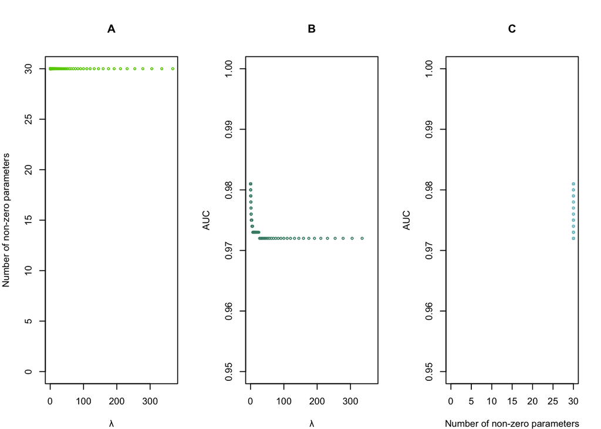

```r
# ridge
par(mfrow=c(1,3), mar=c(4,4,5,2))
plot(bc.ridge.eval.dt$λ, bc.ridge.eval.dt$ModelSize,
     main = "A",
     xlab = 'λ',
     ylab = 'Number of non-zero parameters',
     col = "chartreuse3",
     cex = .5,
     ylim = c(0,30))
plot(bc.ridge.eval.dt$λ, bc.ridge.eval.dt$AUC,
     main = "B",
     xlab = 'λ',
     ylab = 'AUC',
     col = "aquamarine4",
     cex = .5,
     ylim = c(.95, 1))
plot(bc.ridge.eval.dt$ModelSize, bc.ridge.eval.dt$AUC,
     main = "C",
     xlab = 'Number of non-zero parameters',
     ylab = 'AUC',
     col = "cadetblue3",
     cex = .5,
     xlim = c(0,30),
     ylim = c(.95, 1))
```

Plot A illustrates that the choice of the penalty parameter λ has no effect on the model size when fitting ridge regression model to the data. This what we expect, since ridge regression can’t shrink the coefficient of the model parameters to zero and hence can not exclude unsuitable variables from the prediction. Plot B depicts the relationship between the penalty parameter λ and the AUC. AUC increases with decreasing λ, suggesting that there’s a moderately low penalty yields the best results in terms of the AUC.

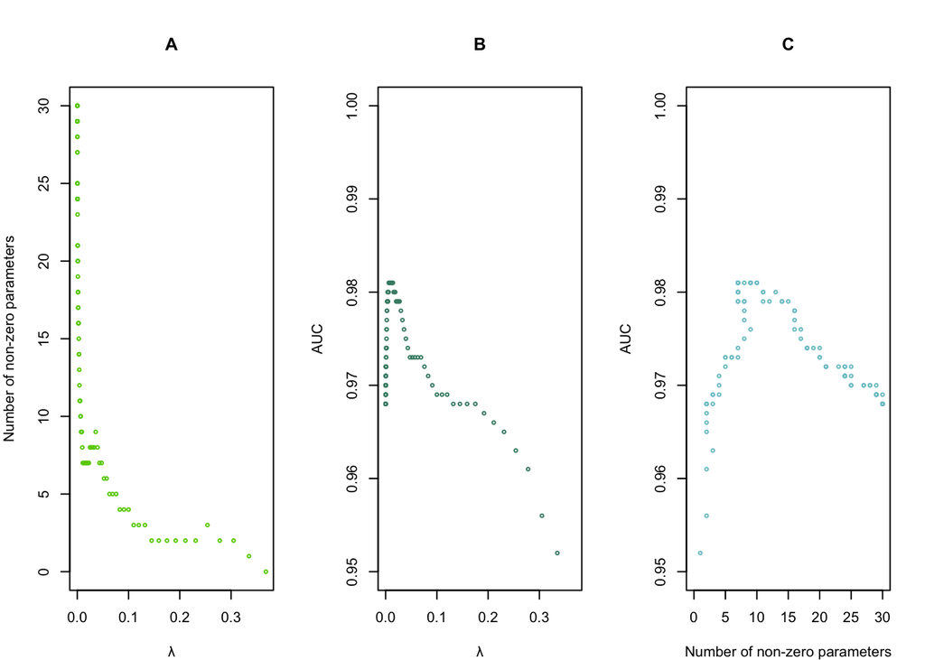

```r
# lasso
par(mfrow=c(1,3), mar=c(4,4,5,2))
plot(bc.lasso.eval.dt$λ, bc.lasso.eval.dt$ModelSize,
     main = "A",
     xlab = 'λ',
     ylab = 'Number of non-zero parameters',
     col = "chartreuse3",
     cex = .5,
     ylim = c(0,30))
plot(bc.lasso.eval.dt$λ, bc.lasso.eval.dt$AUC,
     main = "B",
     xlab = 'λ',
     ylab = 'AUC',
     col = "aquamarine4",
     cex = .5,
     ylim = c(.95, 1))
plot(bc.lasso.eval.dt$ModelSize, bc.lasso.eval.dt$AUC,
     main = "C",
     xlab = 'Number of non-zero parameters',
     ylab = 'AUC',
     col = "cadetblue3",
     cex = .5,
     ylim = c(.95, 1))
```

#### Problem 2 (d)

Performing backwards elimination (model `bc.sel.back`) on the same training set derived at point (a) and

```r
# standardize variables to obtain standardized coefficients
bc.sd1.dt <- copy(bc.dt)
covar.variables <- colnames(bc.dt[, -c("id", "diagnosis")]) # exclude non covariate columns
bc.sd1.dt[, (covar.variables) := lapply(.SD, function(x) x / sd(x, na.rm = TRUE)), .SDcols = covar.variables]

# load library for stepwise regression
library(MASS)

# fit logistic regression model with all training split from (a)
bc.full.model <- glm(diagnosis ~ ., data=bc.sd1.dt[, !"id"], subset = train.idx, family="binomial") # all variables except the patient id

bc.sel.back <- stepAIC(bc.full.model, direction="back")
```

```
## Start:  AIC=145.66
## diagnosis ~ radius + texture + perimeter + area + smoothness +
##     compactness + concavity + concavepoints + symmetry + fractaldimension +
##     radius.stderr + texture.stderr + perimeter.stderr + area.stderr +
##     smoothness.stderr + compactness.stderr + concavity.stderr +
##     concavepoints.stderr + symmetry.stderr + fractaldimension.stderr +
##     radius.worst + texture.worst + perimeter.worst + area.worst +
##     smoothness.worst + compactness.worst + concavity.worst +
##     concavepoints.worst + symmetry.worst + fractaldimension.worst
```

```
##                           Df Deviance    AIC
## - fractaldimension         1   83.665 143.66
## - fractaldimension.worst   1   83.666 143.67
## - texture                  1   83.668 143.67
## - symmetry                 1   83.672 143.67
## - concavepoints.worst      1   83.695 143.69
## - compactness              1   83.708 143.71
## - perimeter.stderr         1   83.716 143.72
## - fractaldimension.stderr  1   83.800 143.80
## - symmetry.worst           1   83.857 143.86
## - area.stderr              1   83.910 143.91
## - smoothness               1   84.108 144.11
## - perimeter.worst          1   84.516 144.52
## - compactness.stderr       1   84.682 144.68
## - smoothness.worst         1   84.703 144.70
## - compactness.worst        1   84.714 144.71
## - symmetry.stderr          1   84.759 144.76
## - radius.worst             1   84.869 144.87
## - perimeter                1   84.989 144.99
## - concavepoints.stderr     1   85.116 145.12
## <none>                         83.665 145.66
## - smoothness.stderr        1   85.815 145.81
## - radius.stderr            1   86.033 146.03
## - texture.stderr           1   86.384 146.38
## - radius                   1   87.016 147.02
## - concavity.worst          1   87.992 147.99
## - area                     1   88.053 148.05
## - texture.worst            1   88.505 148.50
## - concavepoints            1   89.370 149.37
## - concavity                1   89.459 149.46
## - area.worst               1   93.357 153.36
## - concavity.stderr         1   93.811 153.81
##
## Step:  AIC=143.66
## diagnosis ~ radius + texture + perimeter + area + smoothness +
##     compactness + concavity + concavepoints + symmetry + radius.stderr +
##     texture.stderr + perimeter.stderr + area.stderr + smoothness.stderr +
##     compactness.stderr + concavity.stderr + concavepoints.stderr +
##     symmetry.stderr + fractaldimension.stderr + radius.worst +
##     texture.worst + perimeter.worst + area.worst + smoothness.worst +
##     compactness.worst + concavity.worst + concavepoints.worst +
##     symmetry.worst + fractaldimension.worst
```

```
##                           Df Deviance    AIC
## - texture                  1   83.668 141.67
## - fractaldimension.worst   1   83.669 141.67
## - symmetry                 1   83.672 141.67
## - concavepoints.worst      1   83.695 141.69
## - perimeter.stderr         1   83.724 141.72
## - compactness              1   83.731 141.73
## - fractaldimension.stderr  1   83.800 141.80
## - symmetry.worst           1   83.860 141.86
## - area.stderr              1   83.910 141.91
## - smoothness               1   84.109 142.11
## - perimeter.worst          1   84.658 142.66
## - compactness.stderr       1   84.684 142.68
## - smoothness.worst         1   84.704 142.70
## - symmetry.stderr          1   84.761 142.76
## - compactness.worst        1   84.834 142.83
## - radius.worst             1   84.939 142.94
## - perimeter                1   84.992 142.99
## - concavepoints.stderr     1   85.117 143.12
## <none>                         83.665 143.66
## - smoothness.stderr        1   85.830 143.83
## - radius.stderr            1   86.142 144.14
## - texture.stderr           1   86.387 144.39
## - radius                   1   87.138 145.14
## - area                     1   88.079 146.08
## - concavity.worst          1   88.158 146.16
## - texture.worst            1   88.542 146.54
## - concavepoints            1   89.448 147.45
## - concavity                1   89.605 147.60
## - area.worst               1   93.564 151.56
## - concavity.stderr         1   93.886 151.89
##
## Step:  AIC=141.67
## diagnosis ~ radius + perimeter + area + smoothness + compactness +
##     concavity + concavepoints + symmetry + radius.stderr + texture.stderr +
##     perimeter.stderr + area.stderr + smoothness.stderr + compactness.stderr +
##     concavity.stderr + concavepoints.stderr + symmetry.stderr +
##     fractaldimension.stderr + radius.worst + texture.worst +
##     perimeter.worst + area.worst + smoothness.worst + compactness.worst +
##     concavity.worst + concavepoints.worst + symmetry.worst +
##     fractaldimension.worst
```

```
##                           Df Deviance    AIC
## - fractaldimension.worst   1   83.674 139.67
## - symmetry                 1   83.675 139.68
## - concavepoints.worst      1   83.699 139.70
## - perimeter.stderr         1   83.725 139.72
## - compactness              1   83.732 139.73
## - fractaldimension.stderr  1   83.801 139.80
## - symmetry.worst           1   83.891 139.89
## - area.stderr              1   83.911 139.91
## - smoothness               1   84.109 140.11
## - perimeter.worst          1   84.672 140.67
## - compactness.stderr       1   84.703 140.70
## - smoothness.worst         1   84.728 140.73
## - symmetry.stderr          1   84.811 140.81
## - compactness.worst        1   84.842 140.84
## - radius.worst             1   84.981 140.98
## - perimeter                1   84.993 140.99
## - concavepoints.stderr     1   85.139 141.14
## <none>                         83.668 141.67
## - smoothness.stderr        1   85.843 141.84
## - radius.stderr            1   86.199 142.20
## - texture.stderr           1   86.797 142.80
## - radius                   1   87.246 143.25
## - concavity.worst          1   88.172 144.17
## - area                     1   88.464 144.46
## - concavepoints            1   89.502 145.50
## - concavity                1   89.628 145.63
## - area.worst               1   93.570 149.57
## - concavity.stderr         1   94.028 150.03
## - texture.worst            1  100.215 156.22
##
## Step:  AIC=139.67
## diagnosis ~ radius + perimeter + area + smoothness + compactness +
##     concavity + concavepoints + symmetry + radius.stderr + texture.stderr +
##     perimeter.stderr + area.stderr + smoothness.stderr + compactness.stderr +
##     concavity.stderr + concavepoints.stderr + symmetry.stderr +
##     fractaldimension.stderr + radius.worst + texture.worst +
##     perimeter.worst + area.worst + smoothness.worst + compactness.worst +
##     concavity.worst + concavepoints.worst + symmetry.worst
```

```
##                           Df Deviance    AIC
## - symmetry                 1   83.683 137.68
## - concavepoints.worst      1   83.701 137.70
## - compactness              1   83.738 137.74
## - perimeter.stderr         1   83.751 137.75
## - symmetry.worst           1   83.892 137.89
## - area.stderr              1   83.921 137.92
## - fractaldimension.stderr  1   84.024 138.02
## - smoothness               1   84.165 138.16
## - compactness.stderr       1   84.703 138.70
## - smoothness.worst         1   84.771 138.77
## - perimeter.worst          1   84.875 138.88
## - compactness.worst        1   84.941 138.94
## - radius.worst             1   84.991 138.99
## - perimeter                1   84.993 138.99
## - symmetry.stderr          1   85.022 139.02
## - concavepoints.stderr     1   85.169 139.17
## <none>                         83.674 139.67
## - smoothness.stderr        1   85.843 139.84
## - radius.stderr            1   86.313 140.31
## - texture.stderr           1   86.819 140.82
## - radius                   1   87.269 141.27
## - area                     1   88.465 142.47
## - concavity.worst          1   88.469 142.47
## - concavepoints            1   89.633 143.63
## - concavity                1   89.688 143.69
## - concavity.stderr         1   94.321 148.32
## - area.worst               1   94.622 148.62
## - texture.worst            1  100.215 154.22
##
## Step:  AIC=137.68
## diagnosis ~ radius + perimeter + area + smoothness + compactness +
##     concavity + concavepoints + radius.stderr + texture.stderr +
##     perimeter.stderr + area.stderr + smoothness.stderr + compactness.stderr +
##     concavity.stderr + concavepoints.stderr + symmetry.stderr +
##     fractaldimension.stderr + radius.worst + texture.worst +
##     perimeter.worst + area.worst + smoothness.worst + compactness.worst +
##     concavity.worst + concavepoints.worst + symmetry.worst
```

```
##                           Df Deviance    AIC
## - concavepoints.worst      1   83.703 135.70
## - compactness              1   83.740 135.74
## - perimeter.stderr         1   83.764 135.76
## - area.stderr              1   83.924 135.92
## - symmetry.worst           1   83.929 135.93
## - fractaldimension.stderr  1   84.025 136.03
## - smoothness               1   84.169 136.17
## - compactness.stderr       1   84.745 136.75
## - smoothness.worst         1   84.810 136.81
## - perimeter.worst          1   84.894 136.89
## - compactness.worst        1   84.944 136.94
## - radius.worst             1   85.006 137.01
## - perimeter                1   85.032 137.03
## - symmetry.stderr          1   85.071 137.07
## - concavepoints.stderr     1   85.170 137.17
## <none>                         83.683 137.68
## - smoothness.stderr        1   85.844 137.84
## - radius.stderr            1   86.321 138.32
## - radius                   1   87.320 139.32
## - texture.stderr           1   87.375 139.38
## - concavity.worst          1   88.548 140.55
## - area                     1   88.585 140.59
## - concavity                1   89.853 141.85
## - concavepoints            1   89.873 141.87
## - concavity.stderr         1   94.493 146.49
## - area.worst               1   94.672 146.67
## - texture.worst            1  102.657 154.66
##
## Step:  AIC=135.7
## diagnosis ~ radius + perimeter + area + smoothness + compactness +
##     concavity + concavepoints + radius.stderr + texture.stderr +
##     perimeter.stderr + area.stderr + smoothness.stderr + compactness.stderr +
##     concavity.stderr + concavepoints.stderr + symmetry.stderr +
##     fractaldimension.stderr + radius.worst + texture.worst +
##     perimeter.worst + area.worst + smoothness.worst + compactness.worst +
##     concavity.worst + symmetry.worst
```

```
##                           Df Deviance    AIC
## - compactness              1   83.754 133.75
## - perimeter.stderr         1   83.835 133.84
## - area.stderr              1   83.927 133.93
## - symmetry.worst           1   83.942 133.94
## - fractaldimension.stderr  1   84.039 134.04
## - smoothness               1   84.262 134.26
## - compactness.worst        1   84.967 134.97
## - radius.worst             1   85.021 135.02
## - perimeter                1   85.035 135.03
## - compactness.stderr       1   85.052 135.05
## - perimeter.worst          1   85.126 135.13
## - symmetry.stderr          1   85.171 135.17
## - smoothness.worst         1   85.300 135.30
## <none>                         83.703 135.70
## - smoothness.stderr        1   86.186 136.19
## - concavepoints.stderr     1   86.356 136.36
## - radius.stderr            1   86.604 136.60
## - texture.stderr           1   87.437 137.44
## - radius                   1   87.884 137.88
## - area                     1   89.407 139.41
## - concavity.worst          1   89.619 139.62
## - concavity                1   90.889 140.89
## - concavepoints            1   92.806 142.81
## - area.worst               1   94.691 144.69
## - concavity.stderr         1   94.758 144.76
## - texture.worst            1  103.017 153.02
##
## Step:  AIC=133.75
## diagnosis ~ radius + perimeter + area + smoothness + concavity +
##     concavepoints + radius.stderr + texture.stderr + perimeter.stderr +
##     area.stderr + smoothness.stderr + compactness.stderr + concavity.stderr +
##     concavepoints.stderr + symmetry.stderr + fractaldimension.stderr +
##     radius.worst + texture.worst + perimeter.worst + area.worst +
##     smoothness.worst + compactness.worst + concavity.worst +
##     symmetry.worst
```

```
##                           Df Deviance    AIC
## - perimeter.stderr         1   83.870 131.87
## - symmetry.worst           1   83.961 131.96
## - area.stderr              1   83.988 131.99
## - fractaldimension.stderr  1   84.046 132.05
## - smoothness               1   84.277 132.28
## - perimeter                1   85.036 133.04
## - radius.worst             1   85.083 133.08
## - compactness.stderr       1   85.102 133.10
## - perimeter.worst          1   85.188 133.19
## - symmetry.stderr          1   85.271 133.27
## - compactness.worst        1   85.304 133.30
## - smoothness.worst         1   85.325 133.32
## <none>                         83.754 133.75
## - smoothness.stderr        1   86.381 134.38
## - concavepoints.stderr     1   86.383 134.38
## - radius.stderr            1   86.604 134.60
## - texture.stderr           1   87.455 135.46
## - radius                   1   87.923 135.92
## - area                     1   89.480 137.48
## - concavity.worst          1   90.261 138.26
## - concavity                1   91.741 139.74
## - concavepoints            1   92.827 140.83
## - concavity.stderr         1   94.766 142.77
## - area.worst               1   95.320 143.32
## - texture.worst            1  103.039 151.04
##
## Step:  AIC=131.87
## diagnosis ~ radius + perimeter + area + smoothness + concavity +
##     concavepoints + radius.stderr + texture.stderr + area.stderr +
##     smoothness.stderr + compactness.stderr + concavity.stderr +
##     concavepoints.stderr + symmetry.stderr + fractaldimension.stderr +
##     radius.worst + texture.worst + perimeter.worst + area.worst +
##     smoothness.worst + compactness.worst + concavity.worst +
##     symmetry.worst
```

```
##                           Df Deviance    AIC
## - fractaldimension.stderr  1   84.102 130.10
## - symmetry.worst           1   84.103 130.10
## - area.stderr              1   84.119 130.12
## - smoothness               1   84.397 130.40
## - perimeter                1   85.149 131.15
## - symmetry.stderr          1   85.290 131.29
## - compactness.worst        1   85.320 131.32
## - smoothness.worst         1   85.327 131.33
## - compactness.stderr       1   85.350 131.35
## <none>                         83.870 131.87
## - perimeter.worst          1   86.223 132.22
## - smoothness.stderr        1   86.654 132.65
## - radius.worst             1   86.684 132.68
## - concavepoints.stderr     1   87.017 133.02
## - radius                   1   87.988 133.99
## - texture.stderr           1   88.017 134.02
## - area                     1   89.553 135.55
## - concavity.worst          1   90.267 136.27
## - concavity                1   91.749 137.75
## - concavepoints            1   92.856 138.86
## - concavity.stderr         1   95.103 141.10
## - area.worst               1   95.414 141.41
## - radius.stderr            1  101.382 147.38
## - texture.worst            1  103.245 149.25
##
## Step:  AIC=130.1
## diagnosis ~ radius + perimeter + area + smoothness + concavity +
##     concavepoints + radius.stderr + texture.stderr + area.stderr +
##     smoothness.stderr + compactness.stderr + concavity.stderr +
##     concavepoints.stderr + symmetry.stderr + radius.worst + texture.worst +
##     perimeter.worst + area.worst + smoothness.worst + compactness.worst +
##     concavity.worst + symmetry.worst
```

```
##                        Df Deviance    AIC
## - area.stderr           1   84.381 128.38
## - symmetry.worst        1   84.409 128.41
## - smoothness            1   84.549 128.55
## - smoothness.worst      1   85.388 129.39
## - symmetry.stderr       1   85.397 129.40
## - perimeter             1   85.581 129.58
## - compactness.worst     1   85.802 129.80
## <none>                      84.102 130.10
## - perimeter.worst       1   86.509 130.51
## - compactness.stderr    1   86.711 130.71
## - radius.worst          1   86.804 130.80
## - smoothness.stderr     1   87.275 131.28
## - concavepoints.stderr  1   87.368 131.37
## - radius                1   88.057 132.06
## - texture.stderr        1   88.301 132.30
## - area                  1   89.604 133.60
## - concavity.worst       1   91.573 135.57
## - concavity             1   92.297 136.30
## - concavepoints         1   92.873 136.87
## - area.worst            1   95.431 139.43
## - concavity.stderr      1   95.714 139.71
## - radius.stderr         1  101.553 145.55
## - texture.worst         1  103.381 147.38
##
## Step:  AIC=128.38
## diagnosis ~ radius + perimeter + area + smoothness + concavity +
##     concavepoints + radius.stderr + texture.stderr + smoothness.stderr +
##     compactness.stderr + concavity.stderr + concavepoints.stderr +
##     symmetry.stderr + radius.worst + texture.worst + perimeter.worst +
##     area.worst + smoothness.worst + compactness.worst + concavity.worst +
##     symmetry.worst
##
##                        Df Deviance    AIC
## - symmetry.worst        1   84.634 126.63
## - smoothness            1   84.848 126.85
## - smoothness.worst      1   85.685 127.69
## - symmetry.stderr       1   85.767 127.77
## - perimeter             1   85.857 127.86
## - compactness.worst     1   86.189 128.19
```

[output cut: 165 more lines]

```
## - concavepoints.stderr  1   91.221 121.22
## - texture.stderr        1   93.334 123.33
## - symmetry.stderr       1   95.236 125.24
## - smoothness.stderr     1   95.287 125.29
## - radius                1   96.758 126.76
## - concavity             1   97.458 127.46
## - area                  1   98.082 128.08
## - concavity.worst       1  100.821 130.82
## - compactness.stderr    1  101.358 131.36
## - concavity.stderr      1  102.396 132.40
## - concavepoints         1  102.747 132.75
## - radius.worst          1  104.813 134.81
## - area.worst            1  107.691 137.69
## - texture.worst         1  109.354 139.35
## - radius.stderr         1  117.644 147.64
```

Reporting the variables selected and their standardized regression coefficients in decreasing order of the absolute value of their standardized regression coefficient:

```r
# create data table with variable and regression coefs
bc.sel.back.coefs <- data.table("variable" = rownames(coef(summary(bc.sel.back)))[-1],
                               "stdz.coef" = signif(coef(summary(bc.sel.back))[-1,1]))

# sort by absolute value of their standardized regression coefficient (in decreasing order)
bc.sel.back.coefs <- bc.sel.back.coefs[order(-abs(bc.sel.back.coefs$stdz.coef))]

#show results
bc.sel.back.coefs
```

```
##                 variable  stdz.coef
##  1:         radius.worst  15.039200
##  2:           area.worst -12.685400
##  3:        concavepoints   4.427890
##  4:            concavity  -4.135440
##  5:                 area  -3.771410
##  6:        radius.stderr   3.486030
##  7:      concavity.worst   2.956240
##  8:        texture.worst   2.294540
##  9:               radius   2.098950
## 10:     concavity.stderr   1.629230
## 11:   compactness.stderr  -1.625030
## 12:       texture.stderr  -1.118380
## 13: concavepoints.stderr  -1.005400
## 14:      symmetry.stderr   0.973987
## 15:    smoothness.stderr   0.889002
```

#### Problem 2 (e)

Repeating the same analysis of point (d) by using stepwise selection (model `bc.sel.forw`) starting from the null model:

```r
bc.train.dt <- bc.sd1.dt[, !"id"][train.idx]

# fit logistic regression model with all the training split from (a)
bc.null.model <- glm(diagnosis ~ 1, data=bc.sd1.dt[, !"id"], subset = train.idx, family="binomial") # only the intercept

# perform stepwise regression (forward selection)
bc.step.select <- step(bc.null.model, scope=list(upper=bc.full.model),direction="both")
```

```
## Start:  AIC=527.17
## diagnosis ~ 1
##
##                           Df Deviance    AIC
## + perimeter.worst          1   229.75 233.75
## + radius.worst             1   235.73 239.73
## + concavepoints.worst      1   237.34 241.34
## + concavepoints            1   242.84 246.84
## + area.worst               1   254.62 258.62
## + perimeter                1   268.79 272.79
## + radius                   1   274.21 278.21
## + area.stderr              1   293.65 297.65
## + area                     1   297.11 301.11
## + concavity                1   309.39 313.39
## + radius.stderr            1   331.25 335.25
## + perimeter.stderr         1   335.59 339.59
## + concavity.worst          1   342.24 346.24
## + compactness              1   380.30 384.30
## + compactness.worst        1   380.66 384.66
## + texture.worst            1   434.44 438.44
## + texture                  1   444.06 448.06
## + symmetry.worst           1   452.72 456.72
## + concavepoints.stderr     1   453.08 457.08
## + smoothness.worst         1   455.29 459.29
## + smoothness               1   469.90 473.90
## + symmetry                 1   478.39 482.39
## + fractaldimension.worst   1   485.15 489.15
## + compactness.stderr       1   492.10 496.10
## + concavity.stderr         1   497.37 501.37
## + fractaldimension.stderr  1   519.24 523.24
## <none>                         525.17 527.17
## + smoothness.stderr        1   524.16 528.16
## + texture.stderr           1   524.50 528.50
## + symmetry.stderr          1   525.07 529.07
## + fractaldimension         1   525.13 529.13
##
## Step:  AIC=233.75
## diagnosis ~ perimeter.worst
##
##                           Df Deviance    AIC
```

[output cut: 91 more lines]

```
## + smoothness               1   173.82 183.82
## + perimeter                1   174.49 184.49
## + compactness.stderr       1   174.65 184.65
## + compactness              1   174.73 184.73
## + fractaldimension         1   174.88 184.88
## + fractaldimension.worst   1   174.91 184.91
## + texture.worst            1   175.06 185.06
## + compactness.worst        1   175.13 185.13
## + smoothness.stderr        1   175.15 185.15
## - texture                  1   191.15 197.15
## - smoothness.worst         1   212.94 218.94
## - perimeter.worst          1   374.55 380.55
##
## Step:  AIC=174.83
## diagnosis ~ perimeter.worst + smoothness.worst + texture + radius.stderr
```

```
##                           Df Deviance    AIC
## + area.stderr              1   152.37 164.37
## + radius                   1   155.53 167.53
## + area.worst               1   156.13 168.13
## + symmetry.worst           1   156.66 168.66
## + concavity.worst          1   158.18 170.18
## + concavepoints.worst      1   158.34 170.34
## + area                     1   159.11 171.11
## + concavity.stderr         1   159.40 171.40
## + concavity                1   161.28 173.28
## + symmetry                 1   162.74 174.74
## <none>                         164.83 174.83
## + texture.worst            1   162.85 174.85
## + perimeter.stderr         1   162.87 174.87
## + smoothness.stderr        1   162.97 174.97
## + concavepoints.stderr     1   163.54 175.54
## + radius.worst             1   163.70 175.70
## + concavepoints            1   163.82 175.82
## + fractaldimension.worst   1   164.07 176.07
## + compactness.worst        1   164.15 176.15
## + perimeter                1   164.34 176.34
## + symmetry.stderr          1   164.51 176.51
## + fractaldimension.stderr  1   164.56 176.56
## + smoothness               1   164.71 176.71
## + compactness              1   164.80 176.80
## + fractaldimension         1   164.82 176.82
## + compactness.stderr       1   164.82 176.82
## + texture.stderr           1   164.83 176.83
## - radius.stderr            1   175.18 183.18
## - texture                  1   177.90 185.90
## - smoothness.worst         1   205.99 213.99
## - perimeter.worst          1   239.94 247.94
```

```
##
## Step:  AIC=164.37
## diagnosis ~ perimeter.worst + smoothness.worst + texture + radius.stderr +
##     area.stderr
```

[output not shown]

```
##                           Df Deviance    AIC
## + radius                   1   144.01 158.01
## + symmetry.worst           1   146.01 160.01
## + concavity.worst          1   148.21 162.21
## + concavity.stderr         1   149.04 163.04
## + area                     1   149.10 163.10
## + concavepoints.worst      1   149.44 163.44
## + radius.worst             1   149.69 163.69
## + texture.worst            1   149.71 163.71
## + perimeter.stderr         1   150.04 164.04
## <none>                         152.37 164.37
## + concavity                1   150.68 164.68
## + area.worst               1   151.10 165.10
## + symmetry                 1   151.22 165.22
## + smoothness.stderr        1   151.40 165.40
## + smoothness               1   151.72 165.72
## + perimeter                1   151.75 165.75
## + symmetry.stderr          1   151.92 165.92
## + fractaldimension         1   151.99 165.99
## + concavepoints.stderr     1   152.08 166.08
## + compactness              1   152.14 166.14
## + fractaldimension.worst   1   152.22 166.22
## + concavepoints            1   152.26 166.26
## + compactness.worst        1   152.32 166.32
## + fractaldimension.stderr  1   152.34 166.34
## + compactness.stderr       1   152.37 166.37
## + texture.stderr           1   152.37 166.37
## - texture                  1   164.79 174.79
## - area.stderr              1   164.83 174.83
## - radius.stderr            1   170.84 180.84
## - smoothness.worst         1   188.98 198.98
## - perimeter.worst          1   207.92 217.92
```

```
##
## Step:  AIC=158.01
## diagnosis ~ perimeter.worst + smoothness.worst + texture + radius.stderr +
##     area.stderr + radius
```

[output not shown]

```
##                           Df Deviance    AIC
## + symmetry.worst           1   133.16 149.16
## + concavity.worst          1   137.69 153.69
## + texture.worst            1   138.39 154.39
## + area                     1   140.22 156.22
## + concavepoints.worst      1   140.76 156.76
## + area.worst               1   141.59 157.59
## + smoothness.stderr        1   141.70 157.70
## + concavity.stderr         1   141.85 157.85
## <none>                         144.01 158.01
## + symmetry                 1   142.54 158.54
## + perimeter.stderr         1   142.59 158.59
## + concavity                1   142.93 158.93
## + radius.worst             1   143.15 159.15
## + smoothness               1   143.33 159.33
## + fractaldimension.worst   1   143.38 159.38
## + compactness.worst        1   143.40 159.40
## + symmetry.stderr          1   143.60 159.60
## + compactness              1   143.76 159.76
## + perimeter                1   143.86 159.86
## + fractaldimension         1   143.88 159.88
## + concavepoints.stderr     1   143.90 159.90
## + concavepoints            1   143.93 159.93
## + fractaldimension.stderr  1   143.95 159.95
## + texture.stderr           1   143.96 159.96
## + compactness.stderr       1   144.00 160.00
## - perimeter.worst          1   148.86 160.86
## - radius                   1   152.37 164.37
## - area.stderr              1   155.53 167.53
## - texture                  1   158.52 170.52
## - radius.stderr            1   161.60 173.60
## - smoothness.worst         1   188.52 200.52
```

```
##
## Step:  AIC=149.16
## diagnosis ~ perimeter.worst + smoothness.worst + texture + radius.stderr +
##     area.stderr + radius + symmetry.worst
```

[output not shown]

```
##                           Df Deviance    AIC
## + texture.worst            1   129.49 147.49
## + symmetry.stderr          1   129.91 147.91
## - perimeter.worst          1   134.14 148.14
## + concavity.worst          1   130.37 148.37
## + area.worst               1   130.93 148.93
## <none>                         133.16 149.16
## + area                     1   131.30 149.30
## + compactness              1   131.48 149.48
## + symmetry                 1   131.50 149.50
## + fractaldimension         1   131.88 149.88
## + concavepoints.worst      1   131.97 149.97
## + perimeter.stderr         1   132.06 150.06
## + radius.worst             1   132.17 150.17
## + concavity.stderr         1   132.39 150.39
## + compactness.stderr       1   132.42 150.42
## + fractaldimension.stderr  1   132.52 150.52
## + smoothness.stderr        1   132.59 150.59
## + smoothness               1   132.60 150.60
## + compactness.worst        1   132.93 150.93
## + concavepoints.stderr     1   132.98 150.98
## + texture.stderr           1   133.00 151.00
## + concavity                1   133.04 151.04
## + fractaldimension.worst   1   133.05 151.05
## + concavepoints            1   133.14 151.14
## + perimeter                1   133.15 151.15
## - area.stderr              1   141.12 155.12
## - symmetry.worst           1   144.01 158.01
## - radius                   1   146.01 160.01
## - radius.stderr            1   148.05 162.05
## - texture                  1   149.15 163.15
## - smoothness.worst         1   159.73 173.73
```

```
##
## Step:  AIC=147.49
## diagnosis ~ perimeter.worst + smoothness.worst + texture + radius.stderr +
##     area.stderr + radius + symmetry.worst + texture.worst
```

[output not shown]

```
##                           Df Deviance    AIC
## + area.worst               1   123.98 143.99
## - texture                  1   129.50 145.50
## + concavity.worst          1   125.89 145.89
## - perimeter.worst          1   129.93 145.93
## <none>                         129.49 147.49
## + concavepoints.worst      1   127.75 147.75
## + area                     1   128.08 148.08
## + symmetry.stderr          1   128.10 148.10
## + texture.stderr           1   128.14 148.14
## + symmetry                 1   128.27 148.27
## + concavity.stderr         1   128.31 148.31
## + fractaldimension         1   128.63 148.63
## + compactness              1   128.85 148.85
## + perimeter                1   128.85 148.85
## + concavepoints            1   128.92 148.92
## + concavity                1   129.01 149.01
## + fractaldimension.stderr  1   129.13 149.13
## - texture.worst            1   133.16 149.16
## + perimeter.stderr         1   129.19 149.19
## + compactness.stderr       1   129.37 149.37
## + fractaldimension.worst   1   129.37 149.37
## + radius.worst             1   129.44 149.44
## + smoothness.stderr        1   129.46 149.46
## + smoothness               1   129.47 149.47
## + compactness.worst        1   129.47 149.47
## + concavepoints.stderr     1   129.49 149.49
## - area.stderr              1   137.20 153.20
## - symmetry.worst           1   138.39 154.39
## - radius                   1   144.87 160.87
## - radius.stderr            1   145.33 161.33
## - smoothness.worst         1   152.74 168.74
##
## Step:  AIC=143.98
## diagnosis ~ perimeter.worst + smoothness.worst + texture + radius.stderr +
##     area.stderr + radius + symmetry.worst + texture.worst + area.worst
```

```
##                           Df Deviance    AIC
## + radius.worst             1   116.53 138.53
## + perimeter.stderr         1   119.42 141.42
## - texture                  1   124.56 142.56
## + compactness              1   120.87 142.87
## + compactness.worst        1   121.28 143.28
## + texture.stderr           1   121.41 143.41
## + compactness.stderr       1   121.42 143.42
## + symmetry.stderr          1   121.45 143.46
## + fractaldimension         1   121.76 143.76
## <none>                         123.98 143.99
## - area.stderr              1   126.35 144.35
## + concavity.worst          1   122.44 144.44
## + symmetry                 1   122.55 144.55
## + fractaldimension.worst   1   123.11 145.11
## + concavity.stderr         1   123.27 145.26
## + fractaldimension.stderr  1   123.28 145.28
## + smoothness.stderr        1   123.61 145.62
## + smoothness               1   123.62 145.62
## + concavepoints.worst      1   123.64 145.64
## + area                     1   123.72 145.72
## + concavepoints.stderr     1   123.81 145.81
## + concavity                1   123.97 145.97
## + perimeter                1   123.97 145.97
## + concavepoints            1   123.98 145.98
## - perimeter.worst          1   129.35 147.35
## - area.worst               1   129.49 147.49
## - texture.worst            1   130.93 148.93
## - symmetry.worst           1   131.81 149.81
## - radius.stderr            1   133.61 151.61
## - radius                   1   142.68 160.68
## - smoothness.worst         1   144.11 162.11
##
## Step:  AIC=138.53
## diagnosis ~ perimeter.worst + smoothness.worst + texture + radius.stderr +
##     area.stderr + radius + symmetry.worst + texture.worst + area.worst +
##     radius.worst
```

```
##                           Df Deviance    AIC
## + concavity.worst          1   108.92 132.92
## + concavity.stderr         1   110.55 134.55
## - area.stderr              1   116.53 136.53
## - perimeter.worst          1   116.53 136.53
## - texture                  1   116.55 136.55
## + concavity                1   113.09 137.09
## + concavepoints.worst      1   113.46 137.46
## <none>                         116.53 138.53
## + concavepoints.stderr     1   115.29 139.29
## + symmetry.stderr          1   115.48 139.48
## + area                     1   115.70 139.70
## + perimeter                1   115.73 139.73
## + perimeter.stderr         1   115.96 139.96
## - texture.worst            1   120.04 140.04
## + smoothness               1   116.10 140.10
## + compactness.worst        1   116.13 140.13
## + concavepoints            1   116.16 140.16
## + compactness.stderr       1   116.17 140.17
## + compactness              1   116.24 140.24
## + symmetry                 1   116.26 140.26
## + fractaldimension         1   116.42 140.42
## + fractaldimension.stderr  1   116.45 140.45
## + smoothness.stderr        1   116.45 140.45
## + texture.stderr           1   116.45 140.46
## + fractaldimension.worst   1   116.53 140.53
## - radius                   1   123.31 143.31
## - symmetry.worst           1   123.93 143.93
## - radius.worst             1   123.98 143.99
## - radius.stderr            1   127.32 147.32
## - area.worst               1   129.44 149.44
## - smoothness.worst         1   136.75 156.75
##
## Step:  AIC=132.92
## diagnosis ~ perimeter.worst + smoothness.worst + texture + radius.stderr +
##     area.stderr + radius + symmetry.worst + texture.worst + area.worst +
##     radius.worst + concavity.worst
```

```
##                           Df Deviance    AIC
## + compactness.worst        1   101.79 127.79
## + compactness.stderr       1   103.23 129.24
## - texture                  1   108.97 130.97
## + compactness              1   105.10 131.10
## - area.stderr              1   109.19 131.19
## + fractaldimension.worst   1   105.70 131.70
## + fractaldimension         1   106.14 132.14
## <none>                         108.92 132.92
## + area                     1   107.09 133.09
## - texture.worst            1   111.34 133.34
## + fractaldimension.stderr  1   107.46 133.46
## - perimeter.worst          1   111.58 133.58
## + symmetry.stderr          1   107.87 133.87
## + symmetry                 1   108.18 134.18
## + perimeter                1   108.21 134.21
## + texture.stderr           1   108.33 134.33
## + concavity.stderr         1   108.42 134.42
## + concavity                1   108.47 134.47
## + concavepoints            1   108.55 134.55
## - symmetry.worst           1   112.65 134.65
## + smoothness               1   108.67 134.66
## + concavepoints.stderr     1   108.73 134.74
## + smoothness.stderr        1   108.80 134.80
## + perimeter.stderr         1   108.81 134.81
## + concavepoints.worst      1   108.91 134.91
## - radius                   1   114.17 136.17
## - concavity.worst          1   116.53 138.53
## - radius.stderr            1   118.58 140.58
## - smoothness.worst         1   120.40 142.40
## - radius.worst             1   122.44 144.44
## - area.worst               1   124.59 146.59
##
## Step:  AIC=127.79
## diagnosis ~ perimeter.worst + smoothness.worst + texture + radius.stderr +
##     area.stderr + radius + symmetry.worst + texture.worst + area.worst +
##     radius.worst + concavity.worst + compactness.worst
```

```
##                           Df Deviance    AIC
## - texture                  1  101.795 125.80
## - perimeter.worst          1  102.102 126.10
## - area.stderr              1  102.390 126.39
## + area                     1   99.124 127.12
## + compactness.stderr       1   99.553 127.55
## <none>                        101.790 127.79
## + texture.stderr           1  100.120 128.12
## + symmetry.stderr          1  100.130 128.13
## + concavity                1  100.572 128.57
## + fractaldimension         1  100.828 128.83
## + compactness              1  100.841 128.84
## + smoothness.stderr        1  100.924 128.92
## + symmetry                 1  100.938 128.94
## + fractaldimension.stderr  1  101.102 129.10
## + concavepoints.stderr     1  101.190 129.19
## + perimeter                1  101.213 129.21
## + concavepoints.worst      1  101.265 129.26
## + concavepoints            1  101.487 129.49
## - texture.worst            1  105.510 129.51
## - radius                   1  105.603 129.60
## + smoothness               1  101.666 129.67
## + fractaldimension.worst   1  101.676 129.68
## + perimeter.stderr         1  101.780 129.78
## + concavity.stderr         1  101.780 129.78
## - symmetry.worst           1  108.739 132.74
## - compactness.worst        1  108.921 132.92
## - radius.worst             1  111.673 135.67
## - radius.stderr            1  113.632 137.63
## - concavity.worst          1  116.127 140.13
## - smoothness.worst         1  119.176 143.18
## - area.worst               1  122.285 146.28
##
## Step:  AIC=125.79
## diagnosis ~ perimeter.worst + smoothness.worst + radius.stderr +
##     area.stderr + radius + symmetry.worst + texture.worst + area.worst +
##     radius.worst + concavity.worst + compactness.worst
```

```
##                           Df Deviance    AIC
## - perimeter.worst          1  102.164 124.16
## - area.stderr              1  102.392 124.39
## + area                     1   99.276 125.28
## + compactness.stderr       1   99.687 125.69
## <none>                        101.795 125.80
## + texture.stderr           1  100.225 126.22
## + symmetry.stderr          1  100.264 126.26
## + concavity                1  100.577 126.58
## + fractaldimension         1  100.829 126.83
## + compactness              1  100.849 126.85
## + symmetry                 1  100.938 126.94
## + smoothness.stderr        1  101.028 127.03
## + fractaldimension.stderr  1  101.116 127.12
## + concavepoints.stderr     1  101.234 127.23
## + perimeter                1  101.237 127.24
## + concavepoints.worst      1  101.268 127.27
## + concavepoints            1  101.495 127.50
## - radius                   1  105.632 127.63
## + smoothness               1  101.672 127.67
## + fractaldimension.worst   1  101.680 127.68
## + perimeter.stderr         1  101.785 127.78
## + concavity.stderr         1  101.786 127.79
## + texture                  1  101.790 127.79
## - symmetry.worst           1  108.817 130.82
## - compactness.worst        1  108.970 130.97
## - radius.worst             1  111.983 133.98
## - radius.stderr            1  114.140 136.14
## - concavity.worst          1  116.160 138.16
## - smoothness.worst         1  119.572 141.57
## - area.worst               1  122.389 144.39
## - texture.worst            1  123.029 145.03
##
## Step:  AIC=124.16
## diagnosis ~ smoothness.worst + radius.stderr + area.stderr +
##     radius + symmetry.worst + texture.worst + area.worst + radius.worst +
##     concavity.worst + compactness.worst
```

```
##                           Df Deviance    AIC
## - area.stderr              1  102.676 122.68
## + area                     1   99.854 123.85
## + compactness.stderr       1  100.049 124.05
## <none>                        102.164 124.16
## + texture.stderr           1  100.636 124.64
## + symmetry.stderr          1  100.824 124.82
## + fractaldimension         1  101.104 125.10
## + fractaldimension.stderr  1  101.387 125.39
## + concavity                1  101.435 125.44
## + symmetry                 1  101.520 125.52
## + compactness              1  101.520 125.52
## + concavepoints.worst      1  101.538 125.54
## + smoothness.stderr        1  101.657 125.66
## + concavepoints.stderr     1  101.725 125.72
## + perimeter.worst          1  101.795 125.80
## + perimeter                1  101.926 125.93
## + fractaldimension.worst   1  101.930 125.93
## + perimeter.stderr         1  102.012 126.01
## + concavepoints            1  102.030 126.03
## + smoothness               1  102.083 126.08
## - radius                   1  106.100 126.10
## + texture                  1  102.102 126.10
## + concavity.stderr         1  102.162 126.16
## - symmetry.worst           1  108.856 128.86
## - compactness.worst        1  111.696 131.70
## - radius.stderr            1  114.215 134.22
## - concavity.worst          1  116.347 136.35
## - smoothness.worst         1  120.250 140.25
## - radius.worst             1  121.970 141.97
## - area.worst               1  122.411 142.41
## - texture.worst            1  123.112 143.11
##
## Step:  AIC=122.68
## diagnosis ~ smoothness.worst + radius.stderr + radius + symmetry.worst +
##     texture.worst + area.worst + radius.worst + concavity.worst +
##     compactness.worst
##
##                           Df Deviance    AIC
## + area                     1   99.886 121.89
```

[output cut: 53 more lines]

```
## + symmetry                 1   99.758 123.76
## + concavity.stderr         1   99.817 123.82
## + smoothness.stderr        1   99.826 123.83
## + compactness              1   99.830 123.83
## + smoothness               1   99.847 123.85
## + area.stderr              1   99.854 123.85
## + concavepoints.stderr     1   99.871 123.87
## - symmetry.worst           1  104.261 124.26
## - compactness.worst        1  109.991 129.99
## - smoothness.worst         1  113.542 133.54
## - concavity.worst          1  115.657 135.66
## - texture.worst            1  119.746 139.75
## - area.worst               1  124.435 144.44
## - radius.worst             1  124.656 144.66
## - radius.stderr            1  127.753 147.75
```

Reporting the variables selected and their standardized regression coefficients in decreasing order of the absolute value of their standardized regression coefficient:

```r
# create data table with variable and stdz coefs
bc.step.select.coefs <- data.table("variable" = rownames(coef(summary(bc.step.select)))[-1],
                                "stdz.coef" = signif(coef(summary(bc.step.select))[-1,1]))

# sort coefs by absolute value of their standardized regression coefficient (in decreasing order)
bc.step.select.coefs <- bc.step.select.coefs[order(-abs(bc.step.select.coefs$stdz.coef))]

# view results
bc.step.select.coefs
```

```
##              variable  stdz.coef
##  1:      radius.worst  15.493100
##  2:        area.worst -12.754700
##  3:     radius.stderr   2.454320
##  4:   concavity.worst   1.955560
##  5: compactness.worst  -1.672110
##  6:              area  -1.588860
##  7:     texture.worst   1.437130
##  8:  smoothness.worst   1.369650
##  9:            radius   1.121920
## 10:    symmetry.worst   0.679017
```

**Did at any point in this procedure occur that a variable entered the model and was later on discarded? If so which?**

When tracing back all steps of stepwise selection process, it can be observed that variables `perimeter.worst`, `texture` and `area.stderr` where initially added to the model, but were later discarded.

#### Problem 2 (f)

Comparing the goodness of fit of model `bc.sel.back`(backwards elimination) and model `bc.step.select` (stepwise selection): Given that the two models are not nested, we cannot use a likelihood ratio test. But we can still use the AIC and BIC:

```r
#AIC
AIC(bc.sel.back)
```

```
## [1] 121.064
```

```r
AIC(bc.step.select)
```

```
## [1] 121.8862
```

Since model `bc.sel.back` has lower AIC, so it’s tempting to say it’s the better model. BUT:

```r
#BIC
BIC(bc.sel.back)
```

```
## [1] 184.8874
```

```r
BIC(bc.step.select)
```

```
## [1] 165.7648
```

Model `bc.step.select` has lower BIC (which applies a stronger penalty for the use of additional predictors than AIC). So depending on what criteria you judge, `bc.sel.back` or `bc.step.select` will be the better model. However, since the AICs are almost identical, it does not come as a surprise that the BIC of `bc.step.select` is lower, since it has far fewer predictors.

#### Problem 2 (g)

Using model `bc.sel.back` and model `bc.step.select` to predict observations in the training set, and from that compute the training AUC:

```r
# import package to compute and plot area under the curve
library(pROC)
# make predictions
bc.sel.back.pred <- predict(bc.sel.back, newdata=bc.dt[train.idx], type="response")
bc.step.select.pred <- predict(bc.step.select, newdata=bc.dt[train.idx], type="response")

# plot AUCs
par(mfrow=c(1,1))
roc(bc.dt$diagnosis[train.idx], bc.sel.back.pred, plot=TRUE, legacy.axes=TRUE, main = "Training AUCs", col="brown2", lwd = 1.3)
```

```
##
## Call:
## roc.default(response = bc.dt$diagnosis[train.idx], predictor = bc.sel.back.pred,     plot = TRUE, legacy.axes = TRUE, main = "Training AUCs",     col = "brown2", lwd = 1.3)
##
## Data: bc.sel.back.pred in 252 controls (bc.dt$diagnosis[train.idx] benign) < 147 cases (bc.dt$diagnosis[train.idx] malignant).
## Area under the curve: 0.5
```

```r
roc(bc.dt$diagnosis[train.idx], bc.step.select.pred, plot=TRUE, legacy.axes=TRUE, add=TRUE, col="deepskyblue3", lwd = 1.3)
```

```
##
## Call:
## roc.default(response = bc.dt$diagnosis[train.idx], predictor = bc.step.select.pred,     plot = TRUE, legacy.axes = TRUE, add = TRUE, col = "deepskyblue3",     lwd = 1.3)
##
## Data: bc.step.select.pred in 252 controls (bc.dt$diagnosis[train.idx] benign) < 147 cases (bc.dt$diagnosis[train.idx] malignant).
## Area under the curve: 0.5
```

[figure not shown]

```r
legend("bottomright", c("backwards elimination: AUC = 0.992", "stepwise selection: AUC = 0.989"), fill = c("brown2","deepskyblue3"))
```

#### Problem 2 (h)

Using the four models to predict the outcome for the observations in the test set (using the lambda at 1 standard error for the ridge and lasso models)

```r
bc.sel.back.pred.obs <- predict(bc.sel.back, newdata=bc.dt[-train.idx,], type="response")
bc.step.select.pred.obs <- predict(bc.step.select, newdata=bc.dt[-train.idx,], type="response")
bc.ridge.pred.obs <- predict(bc.cv.ridge, newx = x.bc.dt[-train.idx,], type="response", s=bc.cv.ridge$lambda.1se)
bc.lasso.pred.obs <- predict(bc.cv.lasso, newx = x.bc.dt[-train.idx,], type="response", s=bc.cv.lasso$lambda.1se)
```

Plotting the ROC curves of these models (on the same plot, using different colours) and reporting their test AUCs:

```r
# plot test AUCs
par(mfrow=c(1,1))
roc(bc.dt$diagnosis[-train.idx], bc.sel.back.pred.obs, plot=TRUE, legacy.axes=TRUE, main = "Test AUCs",
    col="#FF9900FF", lwd = 3)
```

```
##
## Call:
## roc.default(response = bc.dt$diagnosis[-train.idx], predictor = bc.sel.back.pred.obs,     plot = TRUE, legacy.axes = TRUE, main = "Test AUCs", col = "#FF9900FF",     lwd = 3)
##
## Data: bc.sel.back.pred.obs in 107 controls (bc.dt$diagnosis[-train.idx] benign) < 63 cases (bc.dt$diagnosis[-train.idx] malignant).
## Area under the curve: 0.5
```

```r
roc(bc.dt$diagnosis[-train.idx], bc.step.select.pred.obs, plot=TRUE, legacy.axes=TRUE,
    add=TRUE, col="#33FF00FF", lwd = 3)
```

```
##
## Call:
## roc.default(response = bc.dt$diagnosis[-train.idx], predictor = bc.step.select.pred.obs,     plot = TRUE, legacy.axes = TRUE, add = TRUE, col = "#33FF00FF",     lwd = 3)
##
## Data: bc.step.select.pred.obs in 107 controls (bc.dt$diagnosis[-train.idx] benign) < 63 cases (bc.dt$diagnosis[-train.idx] malignant).
## Area under the curve: 0.5
```

```r
roc(bc.dt$diagnosis[-train.idx], as.vector(bc.ridge.pred.obs), plot=TRUE, legacy.axes=TRUE,
    add=TRUE, col="#0066FFFF", lwd = 3)
```

```
##
## Call:
## roc.default(response = bc.dt$diagnosis[-train.idx], predictor = as.vector(bc.ridge.pred.obs),     plot = TRUE, legacy.axes = TRUE, add = TRUE, col = "#0066FFFF",     lwd = 3)
##
## Data: as.vector(bc.ridge.pred.obs) in 107 controls (bc.dt$diagnosis[-train.idx] benign) < 63 cases (bc.dt$diagnosis[-train.idx] malignant).
## Area under the curve: 0.988
```

```r
roc(bc.dt$diagnosis[-train.idx], as.vector(bc.lasso.pred.obs), plot=TRUE, legacy.axes=TRUE,
    add=TRUE, col="#FF0099FF", lwd = 3)
```

```
##
## Call:
## roc.default(response = bc.dt$diagnosis[-train.idx], predictor = as.vector(bc.lasso.pred.obs),     plot = TRUE, legacy.axes = TRUE, add = TRUE, col = "#FF0099FF",     lwd = 3)
##
## Data: as.vector(bc.lasso.pred.obs) in 107 controls (bc.dt$diagnosis[-train.idx] benign) < 63 cases (bc.dt$diagnosis[-train.idx] malignant).
## Area under the curve: 0.9915
```

[figure not shown]

```r
legend("bottomright", c("backwards elimination: AUC = 0.991", "stepwise selection: AUC = 0.992", "ridge regression: AUC = 0.988", "lasso regression: AUC = 0.992"),
       fill = c("#FF9900FF","#33FF00FF","#0066FFFF", "#FF0099FF"))
```

Comparing the training AUCs with the test AUCs:

```r
# predict the outcome of lasso and ridge for the observations in the training data set
# (using the lambda at 1 standard error for the ridge and lasso models)
bc.ridge.pred <- predict(bc.cv.ridge, newx = x.bc.dt[train.idx,], type="response", s=bc.cv.ridge$lambda.1se)
bc.lasso.pred <- predict(bc.cv.lasso, newx = x.bc.dt[train.idx,], type="response", s=bc.cv.lasso$lambda.1se)

# plot training AUCc
par(mfrow=c(1,1))
roc(bc.dt$diagnosis[train.idx], bc.sel.back.pred, plot=TRUE, legacy.axes=TRUE, main = "Training AUCs",
    col="#FF9900FF", lwd = 3)
```

```
##
## Call:
## roc.default(response = bc.dt$diagnosis[train.idx], predictor = bc.sel.back.pred,     plot = TRUE, legacy.axes = TRUE, main = "Training AUCs",     col = "#FF9900FF", lwd = 3)
##
## Data: bc.sel.back.pred in 252 controls (bc.dt$diagnosis[train.idx] benign) < 147 cases (bc.dt$diagnosis[train.idx] malignant).
## Area under the curve: 0.5
```

```r
roc(bc.dt$diagnosis[train.idx], bc.step.select.pred, plot=TRUE, legacy.axes=TRUE,
    add=TRUE, col="#33FF00FF", lwd = 3)
```

```
##
## Call:
## roc.default(response = bc.dt$diagnosis[train.idx], predictor = bc.step.select.pred,     plot = TRUE, legacy.axes = TRUE, add = TRUE, col = "#33FF00FF",     lwd = 3)
##
## Data: bc.step.select.pred in 252 controls (bc.dt$diagnosis[train.idx] benign) < 147 cases (bc.dt$diagnosis[train.idx] malignant).
## Area under the curve: 0.5
```

```r
roc(bc.dt$diagnosis[train.idx], as.vector(bc.ridge.pred), plot=TRUE, legacy.axes=TRUE,
    add=TRUE, col="#0066FFFF", lwd = 3)
```

```
##
## Call:
## roc.default(response = bc.dt$diagnosis[train.idx], predictor = as.vector(bc.ridge.pred),     plot = TRUE, legacy.axes = TRUE, add = TRUE, col = "#0066FFFF",     lwd = 3)
##
## Data: as.vector(bc.ridge.pred) in 252 controls (bc.dt$diagnosis[train.idx] benign) < 147 cases (bc.dt$diagnosis[train.idx] malignant).
## Area under the curve: 0.9715
```

```r
roc(bc.dt$diagnosis[train.idx], as.vector(bc.lasso.pred), plot=TRUE, legacy.axes=TRUE,
    add=TRUE, col="#FF0099FF", lwd = 3)
```

```
##
## Call:
## roc.default(response = bc.dt$diagnosis[train.idx], predictor = as.vector(bc.lasso.pred),     plot = TRUE, legacy.axes = TRUE, add = TRUE, col = "#FF0099FF",     lwd = 3)
##
## Data: as.vector(bc.lasso.pred) in 252 controls (bc.dt$diagnosis[train.idx] benign) < 147 cases (bc.dt$diagnosis[train.idx] malignant).
## Area under the curve: 0.9782
```

[figure not shown]

```r
legend("bottomright",
       c("backwards elimination: AUC = 0.992", "stepwise selection: AUC = 0.989", "ridge regression: AUC = 0.972", "lasso regression: AUC = 0.978"),
       fill = c("#FF9900FF","#33FF00FF","#0066FFFF", "#FF0099FF"))
```

### Problem 3

#### Problem 3 (a)

Reading file `GDM.raw.txt` into a data table named `gdm.dt`, and storing rsID and coded allele in a separate data table calle `snp.allele.dt`

```r
# read file
gdm.dt <- fread("GDM.raw.txt")

# install package "stringr" if not installed already

if(!"stringr" %in% rownames(installed.packages())) {
  install.packages("stringr") # functions for making regex stuff super intuitive
}

library(stringr) # functions for intuitive working with regex

# define regex
rsID.regex <- "rs\\d+" # to capture rsID
reference.allele.regex <- "[ACGT]$" # to capture the reference allele


rsIDs <- str_extract(colnames(gdm.dt)[-c(1,2,3)], rsID.regex) # extract rsIDs (exclude colums 1-3: id, sex, pheno)
reference.alleles <- str_extract(colnames(gdm.dt)[-c(1,2,3)], reference.allele.regex) # extract all reference alleles (exclude colums 1-3: id, sex, pheno)

# store rsIDs and reference alleles in data table
snp.allele.dt <- data.table( "snp.name" = colnames(gdm.dt)[-c(1,2,3)],
                             "rsID" = str_extract(colnames(gdm.dt)[-c(1,2,3)], rsID.regex),
                             "reference.allele" = str_extract(colnames(gdm.dt)[-c(1,2,3)], reference.allele.regex))

# check results
head(snp.allele.dt)
```

```
##       snp.name      rsID reference.allele
## 1: rs7513574_T rs7513574                T
## 2: rs1627238_A rs1627238                A
## 3: rs1171278_C rs1171278                C
## 4: rs1137100_A rs1137100                A
## 5: rs2568958_A rs2568958                A
## 6: rs1514175_A rs1514175                A
```

Imputing missing values in `gdm.dt`` according to SNP-wise average allele count:

```r
# check number of NAs
table(is.na(gdm.dt))
```

```
##
##  FALSE   TRUE
## 140582    649
```

```r
# SNP-wise imputation
for (colnm in colnames(gdm.dt[,-1])) {
  gdm.dt[[colnm]][is.na(gdm.dt[[colnm]])] <- mean(gdm.dt[[colnm]], na.rm = TRUE)
}

# check numbers of NAs
table(is.na(gdm.dt))
```

```
##
##  FALSE
## 141231
```

#### Problem 3 (b)

Writing a function `univ.glm.test(x, y, order=FALSE)` where x is a data table of SNPs, y is a binary outcome vector, and order is either TRUE or FALSE: Tthe function should fit a logistic regression model for each SNP in x and return a data table containing:

- SNP names,
- regression coefficients,
- odds ratios,
- standard errors
- and p-values.

If order is set to TRUE, the output data table should be ordered by increasing p-value.

```r
univ.glm.test <- function( data, outcome, order=FALSE){

  output <- NULL

  # loop over all SNPs

  for (snp in 1:length(data)){

    # assertion check
    stopifnot(length(outcome) == length(data[[snp]]))

    # fit logistic regression model
    log.regr <- glm(outcome ~ data[[snp]], family = "binomial")

    # regression model summary with beta, std.error and p.value
    log.regr.summary <- data.table(signif(coef(summary(log.regr)),3))[-1,-3] # exclude intercept and t-value

    # add SNP summary to output table
    output <- rbind(output, log.regr.summary)

  }

  # add column of SNP IDs
  output <- cbind(snp.allele.dt$snp.name, output)

  # add colnames to output table
  colnames(output) <- c("snp","beta", "std.error", "p.value")

  # compute odds ratio
  output[, odds.ratio := signif(exp(beta),3)]

  if(order == TRUE){

    # sort output by increasing p-value
    setorder(output, p.value)
  }

  return(output)

}
```

#### Problem 3 (c)

Using function `univ.glm.test()` to run an association study for all the SNPs in `gdm.dt` against having gestational diabetes (column “pheno”):

```r
gdm.snp.dt <- univ.glm.test(gdm.dt[,!c("ID","sex","pheno")], gdm.dt$pheno, order = TRUE)

# check results
head(gdm.snp.dt)
```

```
##             snp   beta std.error  p.value odds.ratio
## 1: rs12243326_A  0.649     0.159 4.27e-05      1.910
## 2:  rs2237897_T -0.444     0.113 8.24e-05      0.641
## 3:  rs2237892_C -0.410     0.111 2.27e-04      0.664
## 4:  rs4506565_T  0.484     0.135 3.31e-04      1.620
## 5:  rs7903146_C  0.482     0.138 4.92e-04      1.620
## 6:  rs7901695_T  0.484     0.142 6.59e-04      1.620
```

For the SNP that is most strongly associated to increased risk of gestational diabetes reporting the summary statistics from the GWAS as well as the 95% and 99% confidence intervals on the odds ratio:

```r
# summary statistic
gdm.snp.dt[p.value == min(p.value)]
```

```
##             snp  beta std.error  p.value odds.ratio
## 1: rs12243326_A 0.649     0.159 4.27e-05       1.91
```

```r
beta1 <- gdm.snp.dt[beta == max(beta), beta]
se1 <- gdm.snp.dt[beta == max(beta), std.error]

# 95% CI
round(exp(beta1 + 1.96 * se1 * c(-1, 1)), 3)
```

```
## [1] 1.036 3.591
```

```r
# 99% CI
round(exp(beta1 + 2.58 * se1 * c(-1, 1)), 3)
```

```
## [1] 0.851 4.370
```

For the SNP with most significant protective effect reporting the summary statistics from the GWAS as well as the 95% and 99% confidence intervals on the odds ratio:

```r
# summary statistic
gdm.snp.dt[odds.ratio == min(odds.ratio)]
```

```
##             snp   beta std.error p.value odds.ratio
## 1: rs11575839_C -0.611     0.376   0.104      0.543
```

```r
beta2 <- gdm.snp.dt[odds.ratio == min(odds.ratio), beta]
se2 <- gdm.snp.dt[odds.ratio == min(odds.ratio), std.error]

# 95% CI
round(exp(beta2 + 1.96 * se2 * c(-1, 1)), 3)
```

```
## [1] 0.260 1.134
```

```r
# 99% CI
round(exp(beta2 + 2.58 * se2 * c(-1, 1)), 3)
```

```
## [1] 0.206 1.432
```

#### Problem 3 (d)

Merging the GWAS results with the table of gene names provided in file `GDM.annot.txt`

```r
# read GDM.annot.txt
gdm.annot.dt <- fread("GDM.annot.txt")

# merge with allele information
gdm.gwas.dt <- merge(snp.allele.dt, gdm.annot.dt,
                     by.x = "rsID", by.y = "snp")

# merge GWAS results
gdm.gwas.dt <- merge(gdm.gwas.dt, gdm.snp.dt,
                     by.x = "snp.name", by.y = "snp")

# convert pos column to numeric
gdm.gwas.dt[, pos := as.numeric(pos)]
```

Reporting SNP name, effect allele, chromosome number and corresponding gene name for all SNPs that have p-value < 10^−4:

```r
# filter results by p-value
hit.snp.dt <- gdm.gwas.dt[p.value < 10^-4]

# select columns
hit.snp.dt[,c(1,5,2,4)]
```

```
##        snp.name       pos       rsID chrom
## 1: rs12243326_A 114788815 rs12243326    10
## 2:  rs2237897_T   2858546  rs2237897    11
```

For all hit SNPs reporting all gene names that are within a 1Mb window from the SNP position on the same chromosome:

```r
# hit no.1
gdm.gwas.dt[chrom == hit.snp.dt$chrom[1]][pos >= hit.snp.dt$pos[1] - 1000000 & pos <= hit.snp.dt$pos[1] + 1000000]$gene
```

```
## [1] "TCF7L2" "TCF7L2" "TCF7L2" "TCF7L2"
```

```r
# hit.no.2
gdm.gwas.dt[chrom == hit.snp.dt$chrom[2]][pos >= hit.snp.dt$pos[2] - 1000000 & pos <= hit.snp.dt$pos[2] + 1000000]$gene
```

```
## [1] "TH"    "KCNQ1" "KCNQ1" "KCNQ1" "KCNQ1"
```

#### Problem (e)

Building a weighted genetic risk score that includes all SNPs with p-value < 10−4, a second score with all SNPs with p-value < 10−3, and a third score that only includes SNPs on the FTO gene:

```r
# ensure that the ordering of SNPs is respected
gdm.gwas.dt <- gdm.gwas.dt[match(colnames(gdm.dt)[-c(1,2,3)], gdm.gwas.dt$snp.name),]

# assertion check that the ordering of SNPs is respected
stopifnot(colnames(gdm.dt)[-c(1,2,3)] == gdm.gwas.dt$snp.name)

# score 1: p.value < 10^-4
gdm1.snp <- gdm.gwas.dt[p.value < 1e-4]
gdm1.grs <- gdm.dt[, .SD, .SDcols = gdm.gwas.dt[p.value < 1e-4]$snp.name]
gdm1.weighted.grs <- as.matrix(gdm1.grs) %*% gdm1.snp$beta

# score 2: p.value < 10^-3
gdm2.snp <- gdm.gwas.dt[p.value < 1e-3]
gdm2.grs <- gdm.dt[, .SD, .SDcols = gdm.gwas.dt[p.value < 1e-3]$snp.name]
gdm2.weighted.grs <- as.matrix(gdm2.grs) %*% gdm2.snp$beta

# score 3: SNP on the FTO gene
gdm3.snp <- gdm.gwas.dt[gene == "FTO"]
gdm3.grs <- gdm.dt[, .SD, .SDcols = gdm.gwas.dt[gene == "FTO"]$snp.name]
gdm3.weighted.grs <- as.matrix(gdm3.grs) %*% gdm3.snp$beta
```

Adding the three scores as columns to the `gdm.dt` data table:

```r
gdm.dt$p4.score <- gdm1.weighted.grs
gdm.dt$p3.score <- gdm2.weighted.grs
gdm.dt$FTO.score <- gdm3.weighted.grs
```

Fitting the three scores in separate logistic regression models to test their association with gestational diabetes:

```r
# score 1: SNPs with p.value < 10^-4
p4.score.log.regr <- glm(pheno ~ p4.score, data = gdm.dt, family = "binomial")
# score 2: SNPs with p.value < 10^-3
p3.score.log.regr <- glm(pheno ~ p3.score, data = gdm.dt, family = "binomial")
# score 3: SNPs on the FTO gene
FTO.score.log.regr <- glm(pheno ~ FTO.score, data = gdm.dt, family = "binomial")
```

```r
# function to fit logistic regression models and calculate odds ratio, 95% CI l and p-value
fit.score.model <- function(formula, data){

  # fit logistic regression model
  log.regr <- glm(formula, data = data, family = "binomial")

  # compute odds ratio, 95% CI and p-value
  odds.ratio <- exp(coef(summary(log.regr))[2,1])
  CI.lower <- exp(confint(log.regr)[2,1])
  CI.upper <- exp(confint(log.regr)[2,2])
  p.value <- coef(summary(log.regr))[2,4]

  # brief summary table of the summary statistics
  gdm.grs.dt <- data.table(rbind(NULL, c(round(odds.ratio,3), round(CI.lower,3), round(CI.upper,3), signif(p.value,3))))
  colnames(gdm.grs.dt) <- c("odds.ratio","2.5%","97.5%","p.value")

  return(gdm.grs.dt)
}
```

Reporting odds ratio, 95% CI and p-value for each model/score:

```r
# function to calculate odds ratio, 95% CI l and p-value for a logistic regression model
model.stats <- function(model){

  # compute odds ratio, 95% CI and p-value
  odds.ratio <- exp(coef(summary(model))[2,1])
  CI.lower <- exp(confint(model)[2,1])
  CI.upper <- exp(confint(model)[2,2])
  p.value <- coef(summary(model))[2,4]

  # brief summary table of the summary statistics
  gdm.grs.dt <- data.table(rbind(NULL, c(round(odds.ratio,3), round(CI.lower,3), round(CI.upper,3), signif(p.value,3))))
  colnames(gdm.grs.dt) <- c("odds.ratio","2.5%","97.5%","p.value")

  return(gdm.grs.dt)
}

# score 1: SNPs with p.value < 10^-4
model.stats(p4.score.log.regr)
```

```
##    odds.ratio  2.5% 97.5%  p.value
## 1:      2.722 1.924 3.889 2.34e-08
```

```r
# score 2: SNPs with p.value < 10^-3
model.stats(p3.score.log.regr)
```

```
##    odds.ratio 2.5% 97.5% p.value
## 1:       1.45 1.28 1.648 8.2e-09
```

```r
# score 3: SNPs on the FTO gene
model.stats(FTO.score.log.regr)
```

```
##    odds.ratio  2.5% 97.5% p.value
## 1:      1.401 0.812 2.429   0.228
```

#### Problem 3 (f)

Reading the file `GDM.test.txt` into variable `gdm.test.dt`:

```r
gdm.test.dt <- fread("GDM.test.txt", stringsAsFactors = TRUE)
```

For the set of patients in `gdm.test.dt`, computing the three genetic risk scores as defined at point (e) using the same set of SNPs and corresponding weights:

```r
# ensure that the ordering of SNPs is respected
gdm.gwas.dt <- gdm.gwas.dt[match(colnames(gdm.test.dt)[-c(1,2,3)], gdm.gwas.dt$rsID),]

# assertion check that the ordering of SNPs is respected
stopifnot(colnames(gdm.test.dt)[-c(1,2,3)] == gdm.gwas.dt$rsID)

# score 1: p.value < 10^-4
gdm.test1.grs <- gdm.test.dt[, .SD, .SDcols = gdm.gwas.dt[p.value < 1e-4]$rsID]
gdm.test1.weighted.grs <- as.matrix(gdm.test1.grs) %*% gdm1.snp$beta

# score 2: p.value < 10^-3
gdm.test2.grs <- gdm.test.dt[, .SD, .SDcols = gdm.gwas.dt[p.value < 1e-3]$rsID]
gdm.test2.weighted.grs <- as.matrix(gdm.test2.grs) %*% gdm2.snp$beta

# score 3: SNP on the FTO gene
gdm.test3.grs <- gdm.test.dt[, .SD, .SDcols = gdm.gwas.dt[gene == "FTO"]$rsID]
gdm.test3.weighted.grs <- as.matrix(gdm.test3.grs) %*% gdm3.snp$beta
```

Adding the three scores as columns to `gdm.test.dt` (hint: use the same column names as before):

```r
gdm.test.dt$p4.score <- gdm.test1.weighted.grs
gdm.test.dt$p3.score <- gdm.test2.weighted.grs
gdm.test.dt$FTO.score <- gdm.test3.weighted.grs
```

#### Problem 3 (g)

Using the logistic regression models fitted at point (e) to predict the outcome of patients in `gdm.test.dt`:

```r
p4.score.pred <- predict(p4.score.log.regr, gdm.test.dt, type="response")
p3.score.pred <- predict(p3.score.log.regr, gdm.test.dt, type="response")
FTO.score.pred <- predict(FTO.score.log.regr, gdm.test.dt, type="response")
```

Computing the test log-likelihood for the predicted probabilities from the three genetic risk score models: (using the binomial likelihood function I assumed)

```r
# for score 1: p.value < 10^-4
p4.score.pred.loglik <- sum(log(p4.score.pred[gdm.test.dt$pheno == 1])) + sum(log(1-p4.score.pred[gdm.test.dt$pheno == 0]))
p4.score.pred.loglik
```

```
## [1] -25.05319
```

```r
# for score 2: p.value < 10^-3
p3.score.pred.loglik <- sum(log(p3.score.pred[gdm.test.dt$pheno == 1])) + sum(log(1-p3.score.pred[gdm.test.dt$pheno == 0]))
p3.score.pred.loglik
```

```
## [1] -24.76943
```

```r
# for score 3: FTO gene
FTO.score.pred.loglik <- sum(log(FTO.score.pred[gdm.test.dt$pheno == 1])) + sum(log(1-FTO.score.pred[gdm.test.dt$pheno == 0]))
FTO.score.pred.loglik
```

```
## [1] -28.05307
```

#### Problem 3 (h)

Performing a meta-analysis of `GDM.study2.txt` containing the summary statistics from a different study on the same set of SNPs and the results obtained at point (c) and producing a summary of the meta-analysis results for the set of SNPs with meta-analysis p-value < 10^−4 sorted by increasing p-value:

```r
# datasets for meta analysis
gdm.gwas2.dt <- fread("GDM.study2.txt")
gdm.gwas1.dt <- gdm.gwas.dt

# harmonize datasets
gdm.gwas2.dt <- gdm.gwas2.dt[snp %in% gdm.gwas.dt$rsID]
gdm.gwas.dt <- gdm.gwas.dt[rsID %in% gdm.gwas2.dt$snp]

# order by chromosome and position
gdm.gwas2.dt <- gdm.gwas2.dt[match(gdm.gwas.dt$rsID, gdm.gwas2.dt$snp),]
stopifnot(all.equal(gdm.gwas.dt$rsID, gdm.gwas2.dt$snp))

# matching alleles
matching.alleles <- gdm.gwas.dt$reference.allele == gdm.gwas2.dt$effect.allele & gdm.gwas.dt$rsID == gdm.gwas2.dt$snp
# flipped alleles
flipping.alleles <- gdm.gwas.dt$reference.allele == gdm.gwas2.dt$other.allele & gdm.gwas.dt$rsID == gdm.gwas2.dt$snp
# unmatched alleles
unmatched.alleles <- matching.alleles == flipping.alleles
# summary
table(matching.alleles, flipping.alleles)
```

```
##                 flipping.alleles
## matching.alleles FALSE TRUE
##            FALSE     2   27
##            TRUE    147    0
```

```r
# ensure that the effect alleles correspond
beta1 <- gdm.gwas1.dt$beta
beta2 <- gdm.gwas2.dt$beta
beta2[flipping.alleles] <- -beta2[flipping.alleles]

# exclude unmatched SNPs
beta1 <- beta1[!unmatched.alleles]
beta2 <- beta2[!unmatched.alleles]

# inverse variance weighting
weight.gwas1 <- 1 / gdm.gwas1.dt$std.error[!unmatched.alleles]^2
weight.gwas2 <- 1 / gdm.gwas2.dt$se[!unmatched.alleles]^2

# computing the meta-analysis effect size
beta.ma <- (weight.gwas1 * beta1 + weight.gwas2 * beta2) / (weight.gwas1 + weight.gwas2)
se.ma <- sqrt(1 / (weight.gwas1 + weight.gwas2))

# calculating p-values of the meta-analysis
pval.ma <- 2 * pnorm(abs(beta.ma / se.ma), lower.tail=FALSE)

# creating summary data table of all SNPs and their corresponding p-values
ma.results.dt <- data.table("snp" = gdm.gwas1.dt$rsID[!unmatched.alleles],
                            "p.value" = pval.ma)

# select for SNPs with meta-analysis p-value < 10^−4
ma.results.dt <- ma.results.dt[p.value < 1e-4]
setorder(ma.results.dt, p.value)

# show
head(ma.results.dt)
```

```
##           snp      p.value
## 1: rs12243326 2.652109e-15
## 2:  rs2237897 3.328281e-09
## 3:  rs3786897 1.435998e-07
## 4:  rs2237892 4.714342e-06
## 5:  rs4506565 3.697496e-05
## 6:  rs7903146 5.233018e-05
```

### Problem 4

Reading file `nki.csv` into a data table named `nki.dt` and creating `nki.genes.dt`, which only contains the gene expression values:

```r
nki.dt <- data.table(read.csv("nki.csv", stringsAsFactors = TRUE))
nki.genes.dt <- nki.dt[, -c(1,2,3,4,5,6)]
```

#### Problem 4 (a)

Computing the matrix of correlations between the gene expression variables, and displaying it so that a block structure is highlighted:

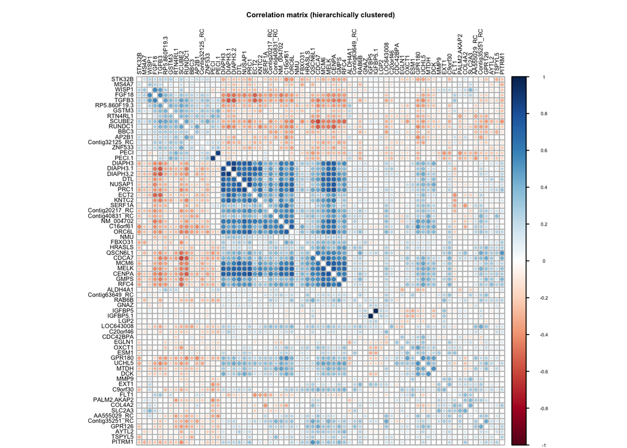

```r
# library for creating corrplots
library(corrplot)
# computing the correlation between the numerical colums `nki.dt`
nki.corr <- cor(nki.genes.dt, use="pairwise.complete")

# correlation plot
par(cex=0.4)
corrplot(nki.corr, order="hclust", diag=FALSE, tl.col="black",
         title="Correlation matrix (hierarchically clustered)",
         mar=c(0,2,4,0))
```

```r
#corrplot(nki.corr, order="FPC", diag=FALSE, tl.col="black",
#         title="Correlation matrix (first principal component order)",
#         mar=c(0,2,4,0))

#corrplot(nki.corr, order="AOE", diag=FALSE, tl.col="black",
#         title="Correlation matrix (angular order of the eigenvectors)",
#         mar=c(0,2,4,0))
```

Writing some code to identify the unique pairs of (distinct) variables that have correlation coefficient greater than 0.80 in absolute value and reporting their correlation coefficients:

```r
corr.pairs <- NULL
# loop over correlation matrix
for (i in 1:nrow(nki.corr)){
  for (j in 1:ncol(nki.corr)){

    # ensure pairs of variables are unique and distinct
    if(i < j){
      # correlation coefficient greater than 0.80 in absolute value
      if(abs(nki.corr[i,j]) > 0.8){
        distinct.unique.pair <- c(rownames(nki.corr)[i], colnames(nki.corr)[j], signif(nki.corr[i,j],3))
        corr.pairs <- rbind(corr.pairs, distinct.unique.pair)
      }
    }
  }
}

# create summary data table
corr.pairs.dt <- data.table(corr.pairs)

# add rownames
colnames(corr.pairs.dt) <- c("gene1", "gene2", "correlation.coeff")

# sort by decreasing correlation coefficient
setorder(corr.pairs.dt, -correlation.coeff)

# view results
corr.pairs.dt
```

```
##       gene1    gene2 correlation.coeff
## 1:   IGFBP5 IGFBP5.1             0.978
## 2: DIAPH3.1 DIAPH3.2             0.887
## 3:     PECI   PECI.1              0.87
## 4:   DIAPH3 DIAPH3.2             0.834
## 5:   NUSAP1     PRC1              0.83
## 6:     PRC1    CENPA             0.818
## 7:   DIAPH3 DIAPH3.1             0.803
```

#### Problem 4 (b)

Running PCA (only over the columns containing gene expressions) so that it is possible to identify variable clusters. Producing a scatter plot of the projection of the predictors on the first two principal components and report the percentage of variance explained by the first two components.

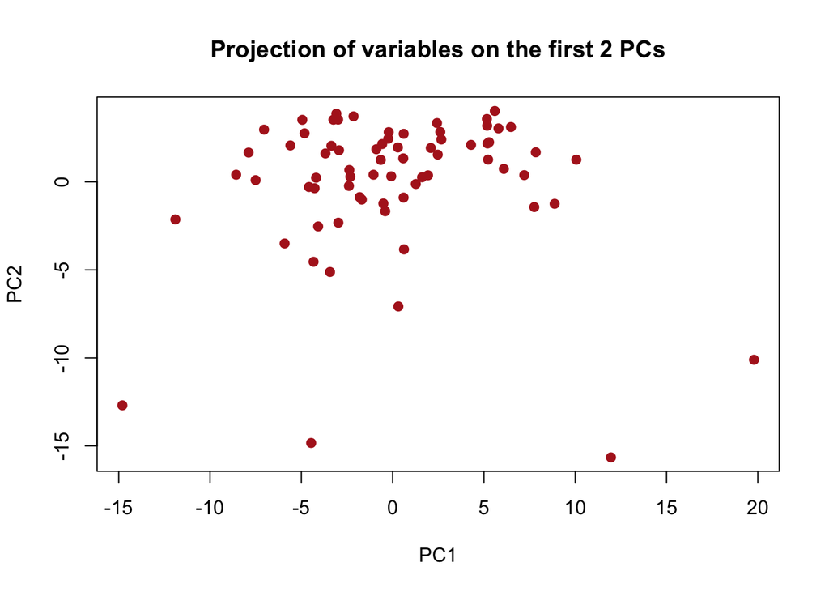

```r
# assertion check whether there are any missing values in nki.dt
stopifnot(sum(is.na(nki.genes.dt)) == 0)

# perform PCA
pca.genes <- prcomp(t(nki.genes.dt), scale = TRUE)

# scatter plot: projection of the predictors on PC1 and PC2
par(cex=1)
plot(pca.genes$x[, 1:2], main="Projection of variables on the first 2 PCs", col = "firebrick", pch=19)
```

```r
# compute percentage of variance explained by the first two components
perc.expl <- pca.genes$sdev^2 / sum(pca.genes$sdev^2)
round(sum(perc.expl[1:2]),3)
```

```
## [1] 0.332
```

The perentage of variance explained by PC1 and PC2 is 33.2%.

Starting from the PCA plot just produced, devising a simple rule PC2 < -10 that identifies the four gene expressions that are most different from the rest and reporting their names:

```r
pca.genes$x[which(pca.genes$x[,"PC2"] < -10), .SD]
```

```
##
## SCUBE2
## MMP9
## ZNF533
## CDCA7
```

#### Problem 4 (c)

Running PCA over the gene expression data again in order to derive a patient-wise summary of all gene expressions (dimensionality reduction), and only keeping the first 3 PCs:

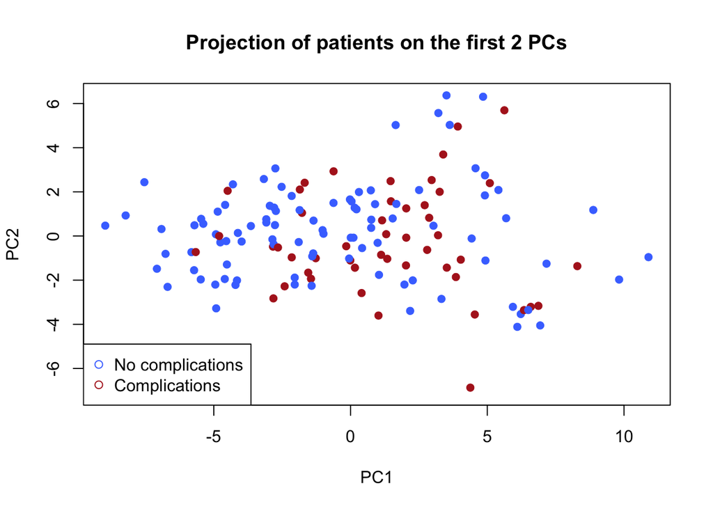

```r
# perform pca
pca.patients <- prcomp(nki.genes.dt, scale = TRUE)

# plot results (outcomes are colour coded)
plot(pca.patients$x[, 1:2], main="Projection of patients on the first 2 PCs",
     col = ifelse(nki.dt$Event == 1, "firebrick", "royalblue1"), pch=19, lwd=0.5)
legend("bottomleft", legend=c("No complications", "Complications"), col = c("royalblue1", "firebrick"), pch = 21)
```

```r
# keep first 3 PCs
top3.PCs <- pca.patients$x[, 1:3]

# add top 3 PCs to nki.dt
nki.dt$PC1 <- top3.PCs[,1]
nki.dt$PC2 <- top3.PCs[,2]
nki.dt$PC3 <- top3.PCs[,3]
```

Testing if those PCs independently are associated with the outcome in unadjusted logistic regression models and in models adjusted for age, estrogen receptor and grade:

```r
# testing PC1
PC1.unadjusted.model <- glm(Event ~ PC1, data = nki.dt, family="binomial")
PC1.adjusted.model <- glm(Event ~ PC1 + Age + EstrogenReceptor + Grade, data = nki.dt, family="binomial")
# beta and p.value of unadjusted model
coef(summary(PC1.unadjusted.model))[2,c(1,4)]
```

```
##    Estimate    Pr(>|z|)
## 0.117683525 0.009425039
```

```r
# beta and p.value of adjusted model
coef(summary(PC1.adjusted.model))[2,c(1,4)]
```

```
##   Estimate   Pr(>|z|)
## 0.07215917 0.27238120
```

```r
# testing PC2
PC2.unadjusted.model <- glm(Event ~ PC2, data = nki.dt, family="binomial")  # unadjusted model
PC2.adjusted.model <- glm(Event ~ PC2 + Age + EstrogenReceptor + Grade, data = nki.dt, family="binomial")  # adjusted model
# beta and p.value of unadjusted model
coef(summary(PC2.unadjusted.model))[2,c(1,4)]
```

```
##   Estimate   Pr(>|z|)
## -0.0671668  0.3885231
```

```r
# beta and p.value of adjusted model
coef(summary(PC2.adjusted.model))[2,c(1,4)]
```

```
##    Estimate    Pr(>|z|)
## 0.005164421 0.955063601
```

```r
# testing PC3
PC3.unadjusted.model <- glm(Event ~ PC3, data = nki.dt, family="binomial")   # unadjusted model
PC3.adjusted.model <- glm(Event ~ PC3 + Age + EstrogenReceptor + Grade, data = nki.dt, family="binomial")  # adjusted model
# beta and p.value of unadjusted model
coef(summary(PC3.unadjusted.model))[2,c(1,4)]
```

```
##  Estimate  Pr(>|z|)
## 0.2435485 0.0086300
```

```r
# beta and p.value of adjusted model
coef(summary(PC3.adjusted.model))[2,c(1,4)]
```

```
##   Estimate   Pr(>|z|)
## 0.21837062 0.02454557
```

**Justifying the difference in results between unadjusted and adjusted models:**

Looking at the results it can be claimed that there is a significant assocation (p < 0.05) between PC1 and the insurgence of further complications after operation, as well as between PC3 and the insurgence of complications. However, this is a hasty conclusion, given that the insurgence of operations for sure also depends on clinical parameters, such as age and tumor classification (estrogen recptor positive or negativ) and tumor staging (differentiation grade). Hence, it is inevitable to test whether the association between the PCs of the gene expression and complications is independent of the most common clinical confounders. In order to test this, we evaluated whether the association between PC1 and complications as well as PC3 and complications are still significant after adjusting for age, estrogen recptor status and differentiation grade, since these variables are known to affect the outcome.

After adjusting for these so called confounders, we can claim there is no significant association between P1 and complications after adjusting for age, estrogen recptor status and differentiation grade. However, we can claim there is a significant association between P3 and complications even after adjusting for these confounders. Hence, we can conclude that the association between PC3 and complications is independent of these confounders, wheras these PC1 and complications is not. Lastly, there is no significant association between PC2 and complications and this does not change after adjusting for the confounders.

#### Problem 4 (d)

Fitting a lasso model to predict the binary outcome using all available predictors, learning the optimal penalty parameter that maximises the AUC. Reporting the results (λ and AUC):

```r
# transforming the data
# predictors
x.nki.dt <- prepare.glmnet(nki.dt[,!c("PC1","PC2","PC3")], ~ . - Event) # exclude the outcome
# outcome
y.nki.dt <- nki.dt$Event
# set.seed
set.seed(1)

# fitting a lasso model and learning by cross-validation the penalty parameter λ that maximizes the AUC

nki.cv.lasso1 <- cv.glmnet(x.nki.dt, y.nki.dt, family="binomial", type.measure="auc")

# penalty parameters λ that maximizes the AUC
nki.cv.lasso1$lambda.min
```

```
## [1] 0.01974088
```

```r
# max AUC
nki.cv.lasso1$cvm[which(nki.cv.lasso1$lambda == nki.cv.lasso1$lambda.min)]
```

```
## [1] 0.7854173
```

System run time on my machine was 0.013s (recorded with `system.time()`).

Repeating the same procedure but this time penalising only to the gene expression variables, leaving all other covariates unpenalised. Reporting the results (λ and AUC):

```r
nki.cv.lasso2 <- cv.glmnet(x.nki.dt, y.nki.dt, penalty.factor = c( rep(0, 5), rep(1,71)),
                          family="binomial", type.measure="auc")

# penalty parameters λ that maximizes the AUC
nki.cv.lasso2$lambda.min
```

```
## [1] 0.00337867
```

```r
# max AUC
nki.cv.lasso2$cvm[which(nki.cv.lasso2$lambda == nki.cv.lasso2$lambda.min)]
```

```
## [1] 0.7404656
```

System run time on my machine was 0.033s (recorded with `system.time()`).

**Can you explain the difference between the two models in terms of AUC?**

In 4 (d) we observed, that the AUC of the model that penalises all covariates is 0.79 and therefore roughly 0.05 higher than that of the model that only penalises the gene expression values (0.74). In 4 (c) we have shown that PC1 and PC2 of of the gene expression values are not significantly associated with complications after adjusting for confounders, whereas PC3 is significantly associated with complications. However, 4 (c) also revealed that when adjusting PC1, PC2 or PC3, all confounders except age were not significantly associated with complications either. This suggests, that they are not the best predictors by themselves and explains why excluding the confounders from the LASSO penalty yields worse results (in terms of AUC) compared to the model where the lasso penalty is applied to all variables.